# PC1 - Minería de Datos

Anilda Guevara

2019-07-17

# 1. Cual es el supuesto de aleatoriedad con el trabaja el paquete mice.

La imputación multivariada mediante ecuaciones encadenadas (MICE) es una técnica particular de imputación múltiple. MICE opera por default bajo el supuesto: dadas las variables utilizadas en el procedimiento de imputación, los datos son missing at random (MAR), lo que significa que la probabilidad de que falte un valor depende solo de los valores observados y no de los valores no observados. En otras palabras, después de controlar todos los datos disponibles “cualquier missing value es completamente aleatorio”. MICE también puede manejar el supuesto missing not at random (MNAR) que requiere supuestos de modelado adicionales que influyen en las imputaciones generadas.

En el procedimiento MICE se ejecutan una serie de modelos de regresión en los que cada variable con datos faltantes se modela condicionalmente a las otras variables. Esto significa que cada variable se puede modelar de acuerdo con su distribución, por ejemplo, las variables binarias pueden ser modeladas usando regresión logística y las variables continuas modeladas usando regresión lineal.

# 2. Utilizando el conjunto de datos, iris2.csv, haga un breve análisis descriptivo (incluya tablas, gráficos) y las interpretaciones que crea conveniente. Utilice un paquete o paquetes de R para realizar las imputaciones al conjunto de datos y haga comparaciones (considere por ejemplo RMSE normalizado)

# Carga de la base de datos y descripción de las variables

El conjunto de datos iris está compuesto de 150 filas y 5 variables, de las cuales 4 son numéricas y 1 es de tipo character (Species)

```
## Classes 'data.table' and 'data.frame':   150 obs. of  6 variables:
##  $ V1          : int  1 2 3 4 5 6 7 8 9 10 ...
##  $ Sepal.Length: num  5.1 4.9 4.7 4.6 5 5.4 4.6 5 4.4 4.9 ...
##  $ Sepal.Width : num  3.5 NA 3.2 3.1 3.6 3.9 3.4 3.4 2.9 3.1 ...
##  $ Petal.Length: num  NA 1.4 1.3 1.5 1.4 1.7 1.4 1.5 1.4 1.5 ...
##  $ Petal.Width : num  0.2 0.2 0.2 0.2 0.2 0.4 0.3 0.2 0.2 NA ...
##  $ Species     : chr  "setosa" "setosa" "setosa" "setosa" ...
##  - attr(*, ".internal.selfref")=<externalptr>
```

```
## [1] 150   6
```

Así también podemos observar que de las 5 variables que contiene la base de datos 3 tienen valores perdidos o missing:

```
##   Sepal.Length    Sepal.Width     Petal.Length    Petal.Width
##  Min.   :4.300   Min.   :2.000   Min.   :1.100   Min.   :0.100
##  1st Qu.:5.100   1st Qu.:2.800   1st Qu.:1.500   1st Qu.:0.300
##  Median :5.800   Median :3.000   Median :4.200   Median :1.300
##  Mean   :5.843   Mean   :3.055   Mean   :3.624   Mean   :1.178
##  3rd Qu.:6.400   3rd Qu.:3.300   3rd Qu.:5.100   3rd Qu.:1.800
##  Max.   :7.900   Max.   :4.400   Max.   :6.900   Max.   :2.500
##                  NA's   :20      NA's   :30      NA's   :15
##    Species
##  Length:150
##  Class :character
##  Mode  :character
##
##
##
##
```

# Análisis descriptivo

Antes de inciar con la imputación de las 3 variables que contienen valores perdidos, analizaremos de las medias de las variables por el tipo de especie: Setosa, Versicolor y Virginica.

En el siguiente cuadro podemos apreciar, que las medias (sin considerar valores perdidos), que tienen mayor distancia entre especies son las relacionadas a “Petal” (Petal.Width y Petal.Length). Cuando realicemos la imputaciónde los datos, se espera que las medias y éste análisis no sea similar.

```r
medias_sin_imputar= data_iris[ , .(media.Sepal.Length=mean(na.omit(Sepal.Length)),
                                   media.Sepal.Width=mean(na.omit(Sepal.Width)),
                                   media.Petal.Length=mean(na.omit(Petal.Length)),
                                   media.Petal.Width=mean(na.omit(Petal.Width))), by=(Species)]
medias_sin_imputar
```

```
##       Species media.Sepal.Length media.Sepal.Width media.Petal.Length
## 1:     setosa              5.006          3.434884           1.473333
## 2: versicolor              5.936          2.757778           4.278947
## 3:  virginica              6.588          2.983333           5.567568
##    media.Petal.Width
## 1:         0.2521739
## 2:         1.3191489
## 3:         2.0333333
```

Lo mencionado en el parráfo anterior, también lo podemos observar mediante un gráficos de dispersión,boxplot y densidades:

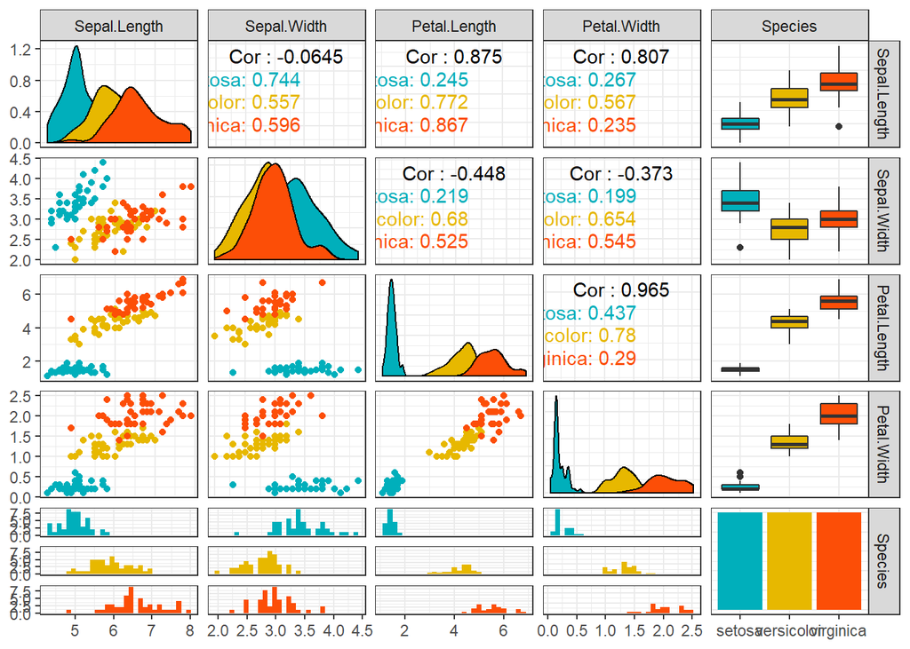

```r
p=ggpairs(data_iris[,c(-1)], aes(color= Species))+ theme_bw()

for(i in 1:p$nrow) {
  for(j in 1:p$ncol){
    p[i,j] = p[i,j]+
      scale_fill_manual(values=c("#00AFBB", "#E7B800", "#FC4E07")) +
      scale_color_manual(values=c("#00AFBB", "#E7B800", "#FC4E07"))
    }
};p
```

# Análisis de valores perdidos

Procedemos a realizar una visualización de la cantidad de valores perdidos en cada variable:

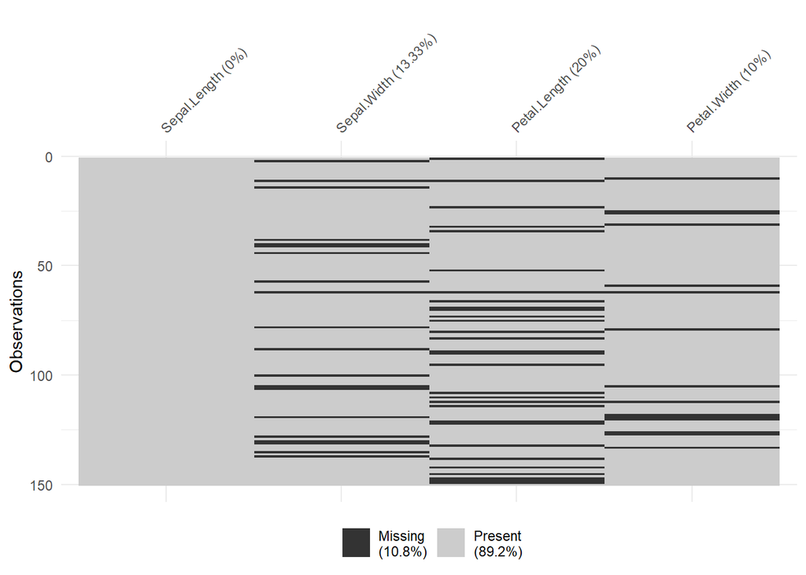

```r
vis_miss(data_iris[,2:5])
```

- Sepal Length tiene completos sus datos
- Sepal Width tiene el 13.33% de los datos con NA
- Petal Length tiene el 20% de los datos con NA
- Petal Width tiene el 10% de los datos con NA

En general el 10.8% de la data tiene valores perdidos.

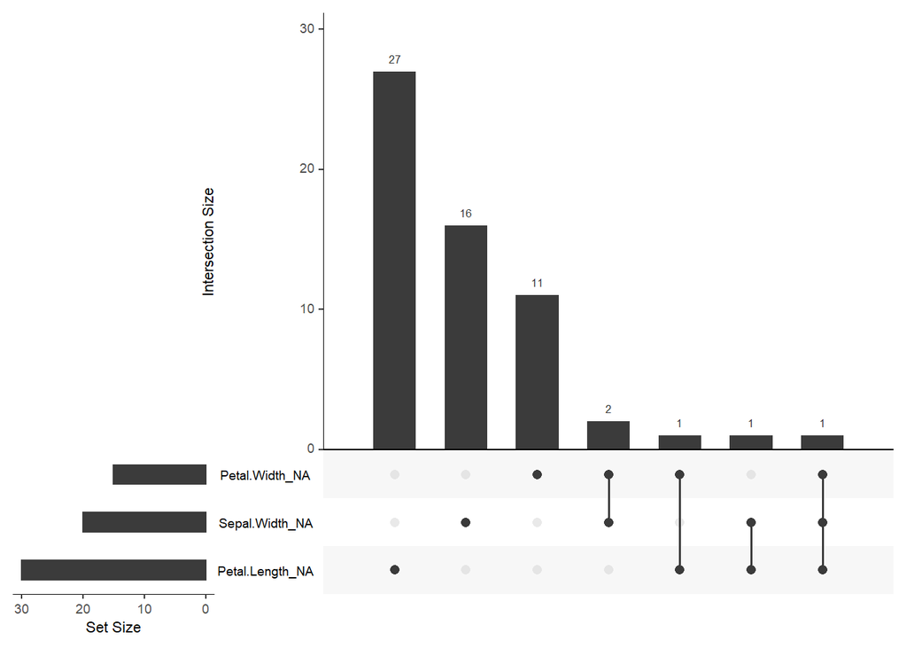

```r
gg_miss_upset(data_iris[,2:5])
```

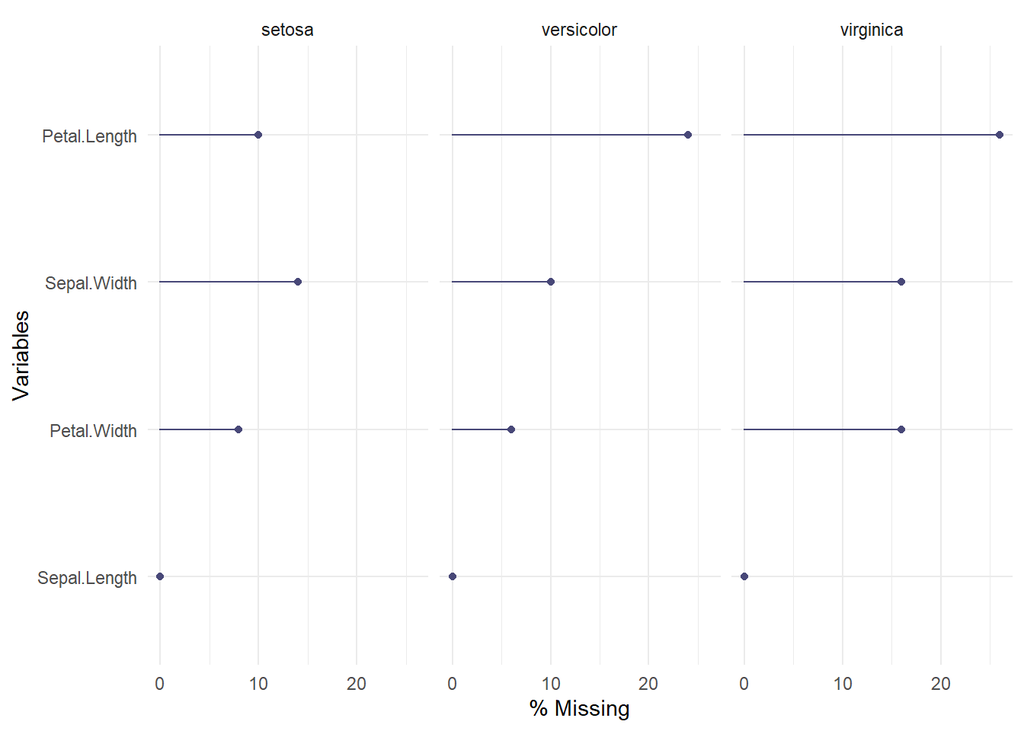

```r
gg_miss_var(data_iris[,2:6],
            show_pct = TRUE ,
            facet = Species)
```

En este gráfico se observan el número de registros con valores perdidos por variale y Specie, observándose que para Specie Setosa la variable con mayor volumen de valores perdidos es Sepal Width mientras que para las Species Vesicolor y Virginia es la variable Petal Length.

## Imputaciones

A continuación se realizan las impuestaciones con los paquetes MICE y VIM. En el caso de MICE se utiliza se utiliza la media y luego el algortitmo “predictive mean matching”; posteriormente se realizar las comparaciones.

**Imputaciones con el algoritmo “Pmm” con el paquete Mice**

En la función “mice” colocamos el método de imputación “pmm” debido a que se realiazan imputaciones sobre variables numéricas:

```r
imputed.mice.pmm= mice(data_iris[,2:6],
              m=5,
              maxit = 50,
              meth= 'pmm',
              seed=23109, print=FALSE)
imputed.data.mice.pmm=complete(imputed.mice.pmm,1)
```

Verificamos si efectivamente ya no existen valores vacíos en la data iris

```r
sapply(imputed.data.mice.pmm, function(x) sum(is.na(x)))
```

```
## Sepal.Length  Sepal.Width Petal.Length  Petal.Width      Species
##            0            0            0            0            0
```

Se realiza nuevamente las correlaciones y las medias de las variables según “Species” considerando los valores imputados por el algoritmo pmm del paquete “Mice”

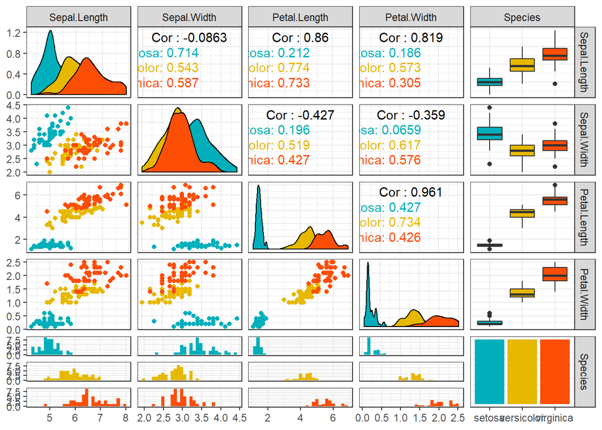

```r
## Variables con Specie
p2=ggpairs(imputed.data.mice.pmm, aes(color= Species))+ theme_bw()

for(i in 1:p2$nrow) {
  for(j in 1:p2$ncol){
    p2[i,j] = p2[i,j]+
      scale_fill_manual(values=c("#00AFBB", "#E7B800", "#FC4E07")) +
      scale_color_manual(values=c("#00AFBB", "#E7B800", "#FC4E07"))
  }
}
p2
```

Si comparamos con las medias imputadas con el algoritmo “pmm” del paquete “Mice” con las medias de las variables por especie que no contenian los valores perdidos, podemos observar que las diferencias son mínimas. Sin embargo, procederemos a realizar imputación con la media y otro paquete para medir su eficiencia y compararlo con otros algoritmos.

```r
imputed.data.mice.pmm=data.table(imputed.data.mice.pmm)
medias_sin_imputar
```

```
##       Species media.Sepal.Length media.Sepal.Width media.Petal.Length
## 1:     setosa              5.006          3.434884           1.473333
## 2: versicolor              5.936          2.757778           4.278947
## 3:  virginica              6.588          2.983333           5.567568
##    media.Petal.Width
## 1:         0.2521739
## 2:         1.3191489
## 3:         2.0333333
```

```r
imputed.data.mice.pmm[ , .(media.Sepal.Length=mean(na.omit(Sepal.Length)),
               media.Sepal.Width=mean(na.omit(Sepal.Width)),
               media.Petal.Length=mean(na.omit(Petal.Length)),
               media.Petal.Width=mean(na.omit(Petal.Width))), by=(Species)]
```

```
##       Species media.Sepal.Length media.Sepal.Width media.Petal.Length
## 1:     setosa              5.006             3.424              1.464
## 2: versicolor              5.936             2.784              4.316
## 3:  virginica              6.588             2.970              5.554
##    media.Petal.Width
## 1:             0.260
## 2:             1.328
## 3:             2.024
```

**Imputaciones con la media con el paquete Mice**

Modificamos en la función “mice” el método a “mean”:

```r
imputed.mice.mean= mice(data_iris[,2:6],
               m=5,
               maxit = 50,
               meth= 'mean',
               seed=23109, print=FALSE)
imputed.data.mice.mean=complete(imputed.mice.mean,1)
```

Verificamos si efectivamente ya no existen valores vacíos en la data iris:

```r
sapply(imputed.data.mice.mean, function(x) sum(is.na(x)))
```

```
## Sepal.Length  Sepal.Width Petal.Length  Petal.Width      Species
##            0            0            0            0            0
```

Se realiza nuevamente las correlaciones y las medias de las variables según “Species” considerando los valores imputados com la media del paquete “Mice”

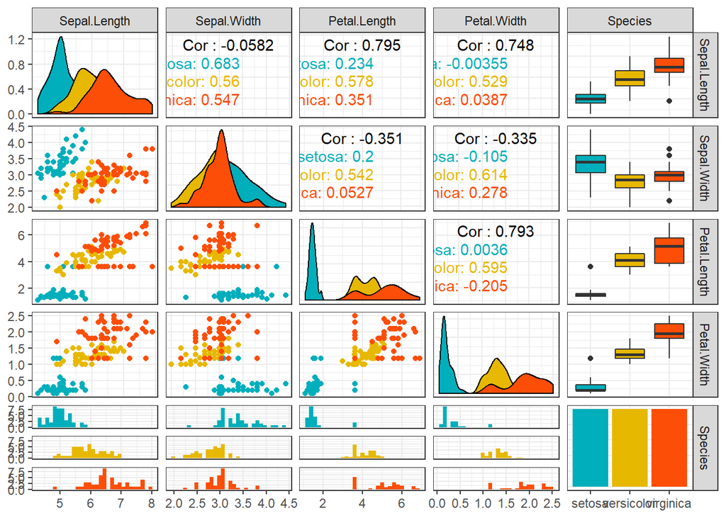

```r
p2=ggpairs(imputed.data.mice.mean, aes(color= Species))+ theme_bw()
for(i in 1:p2$nrow) {
  for(j in 1:p2$ncol){
    p2[i,j] = p2[i,j]+
      scale_fill_manual(values=c("#00AFBB", "#E7B800", "#FC4E07")) +
      scale_color_manual(values=c("#00AFBB", "#E7B800", "#FC4E07"))
  }
}

p2
```

Si comparamos con las medias imputadas con la media del paquete “Mice” con las medias de las variables por especie que no contenian los valores perdidos, podemos observar que las medias con éste método son más distantes comparadas con las medias de los datos antes de imputar. Sin embargo,lo mencionado se verificará con el cálculo y comparación del RMSE de los métodos de imputación utilizados.

```r
imputed.data.mice.mean=data.table(imputed.data.mice.mean)
medias_sin_imputar
```

```
##       Species media.Sepal.Length media.Sepal.Width media.Petal.Length
## 1:     setosa              5.006          3.434884           1.473333
## 2: versicolor              5.936          2.757778           4.278947
## 3:  virginica              6.588          2.983333           5.567568
##    media.Petal.Width
## 1:         0.2521739
## 2:         1.3191489
## 3:         2.0333333
```

```r
imputed.data.mice.mean[ , .(media.Sepal.Length=mean(na.omit(Sepal.Length)),
               media.Sepal.Width=mean(na.omit(Sepal.Width)),
               media.Petal.Length=mean(na.omit(Petal.Length)),
               media.Petal.Width=mean(na.omit(Petal.Width))), by=(Species)]
```

```
##       Species media.Sepal.Length media.Sepal.Width media.Petal.Length
## 1:     setosa              5.006          3.381646           1.688417
## 2: versicolor              5.936          2.787462           4.121800
## 3:  virginica              6.588          2.994738           5.062283
##    media.Petal.Width
## 1:         0.3262222
## 2:         1.3106667
## 3:         1.8964444
```

**Imputaciones con el paquete VIM**

```r
str(data_iris[,c(2:6)])
```

```
## Classes 'data.table' and 'data.frame':   150 obs. of  5 variables:
##  $ Sepal.Length: num  5.1 4.9 4.7 4.6 5 5.4 4.6 5 4.4 4.9 ...
##  $ Sepal.Width : num  3.5 NA 3.2 3.1 3.6 3.9 3.4 3.4 2.9 3.1 ...
##  $ Petal.Length: num  NA 1.4 1.3 1.5 1.4 1.7 1.4 1.5 1.4 1.5 ...
##  $ Petal.Width : num  0.2 0.2 0.2 0.2 0.2 0.4 0.3 0.2 0.2 NA ...
##  $ Species     : chr  "setosa" "setosa" "setosa" "setosa" ...
##  - attr(*, ".internal.selfref")=<externalptr>
```

```r
data=as.data.frame(data_iris[,c(2:6)])
data$Species=as.factor(data$Species)
set.seed(23109)
imputed.irmi= irmi(data)
imputedData.irmi=imputed.irmi[,c(1:5)]
```

Verificamos si efectivamente ya no existen valores vacíos en la data iris

```r
sapply(imputedData.irmi, function(x) sum(is.na(x)))
```

```
## Sepal.Length  Sepal.Width Petal.Length  Petal.Width      Species
##            0            0            0            0            0
```

Se realizan nuevamente loa gráficos de correlación y dispersión de los data que contiene la imputación realizada del paquete “VIM”

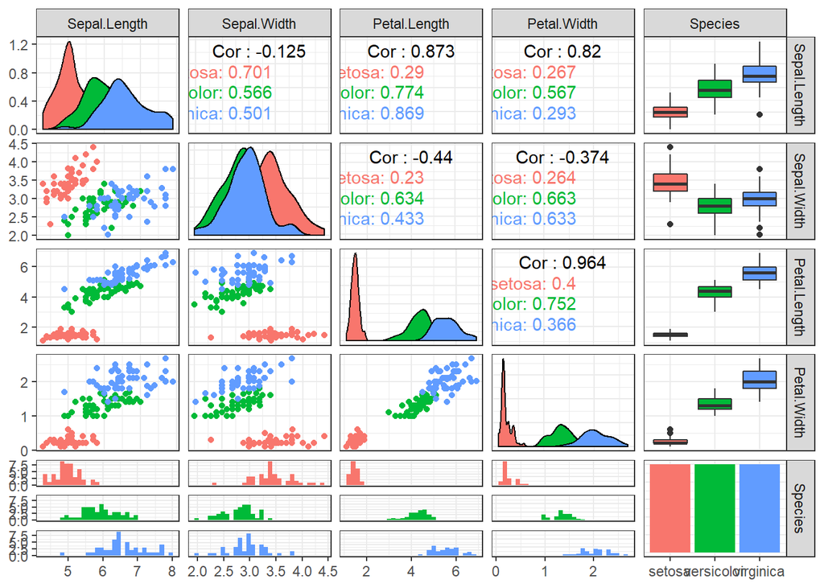

```r
p3=ggpairs(imputedData.irmi, aes(color= Species))+ theme_bw()

for(i in 1:p2$nrow) {
  for(j in 1:p2$ncol){
    p2[i,j] = p2[i,j]+
      scale_fill_manual(values=c("#00AFBB", "#E7B800", "#FC4E07")) +
      scale_color_manual(values=c("#00AFBB", "#E7B800", "#FC4E07"))
  }
};p3
```

Si comparamos con las medias imputadas con el paquete “VIM” con las medias de las variables por especie que no contenian los valores perdidos, podemos observar que las medias con éste método son muy parecudas a las medias de los datos antes de imputar y a las obtenidas con el algoritmo “pmm”. Ahora si procederemos a comparar numéricamente los métodos de imputación aplicados.

```r
imputedData.irmi=data.table(imputedData.irmi)
medias_sin_imputar
```

```
##       Species media.Sepal.Length media.Sepal.Width media.Petal.Length
## 1:     setosa              5.006          3.434884           1.473333
## 2: versicolor              5.936          2.757778           4.278947
## 3:  virginica              6.588          2.983333           5.567568
##    media.Petal.Width
## 1:         0.2521739
## 2:         1.3191489
## 3:         2.0333333
```

```r
imputedData.irmi[ , .(media.Sepal.Length=mean(na.omit(Sepal.Length)),
               media.Sepal.Width=mean(na.omit(Sepal.Width)),
               media.Petal.Length=mean(na.omit(Petal.Length)),
               media.Petal.Width=mean(na.omit(Petal.Width))), by=(Species)]
```

```
##       Species media.Sepal.Length media.Sepal.Width media.Petal.Length
## 1:     setosa              5.006          3.440745           1.485362
## 2: versicolor              5.936          2.790317           4.305839
## 3:  virginica              6.588          2.948364           5.580580
##    media.Petal.Width
## 1:         0.2494764
## 2:         1.3345549
## 3:         2.0358964
```

Para evaluar el mejor método de imputación calculamos la raíz del error cuadrático medio (RSME) entre dos vectores numéricos; mice con pmm e irmi (del paquete VIM) presentan los mejores resultados de RMSE frente a la imputación con la media que data un RMSE de 0.75.

```r
## data True
data(iris)

### RMSE - pmm
RMSE.pmm=Rmse(imputed.data.mice.pmm[,1:4],as.data.frame(data_iris)[,2:5], iris[,1:4], norm = TRUE)

### RMSE - media
RMSE.media=Rmse(imputed.data.mice.mean[,1:4],as.data.frame(data_iris)[,2:5], iris[,1:4], norm = TRUE)

### RMSE - irmi
RMSE.irmi=Rmse(imputedData.irmi[,1:4],as.data.frame(data_iris)[,2:5], iris[,1:4], norm = TRUE)

cbind(RMSE.pmm,RMSE.media,RMSE.irmi)
```

```
##       RMSE.pmm RMSE.media RMSE.irmi
## [1,] 0.2580575  0.7475692 0.2029624
```

**Gráficos de densidad de los métodos de imputación utilizados**

Se han realizado gráficos de densidad de las variables imputadas según especie y se obsevará las diferencias obtenidas por cada método de imputación aplicado:

```r
### Separamos las datas por Especie
iris=data.table(iris)
iris.setosa=iris[Species=="setosa",]
imputed.data.mice.mean.setosa=imputed.data.mice.mean[Species=="setosa",]
imputed.data.mice.pmm.setosa=imputed.data.mice.pmm[Species=="setosa",]
imputed.data.irmi.setosa=imputedData.irmi[Species=="setosa",]

iris.virginica=iris[Species=="virginica",]
imputed.data.mice.mean.virginica=imputed.data.mice.mean[Species=="virginica",]
imputed.data.mice.pmm.virginica=imputed.data.mice.pmm[Species=="virginica",]
imputed.data.irmi.virginica=imputedData.irmi[Species=="virginica",]

iris.versicolor=iris[Species=="versicolor",]
imputed.data.mice.mean.versicolor=imputed.data.mice.mean[Species=="versicolor",]
imputed.data.mice.pmm.versicolor=imputed.data.mice.pmm[Species=="versicolor",]
imputed.data.irmi.versicolor=imputedData.irmi[Species=="versicolor",]
```

- Especie - Setosa:

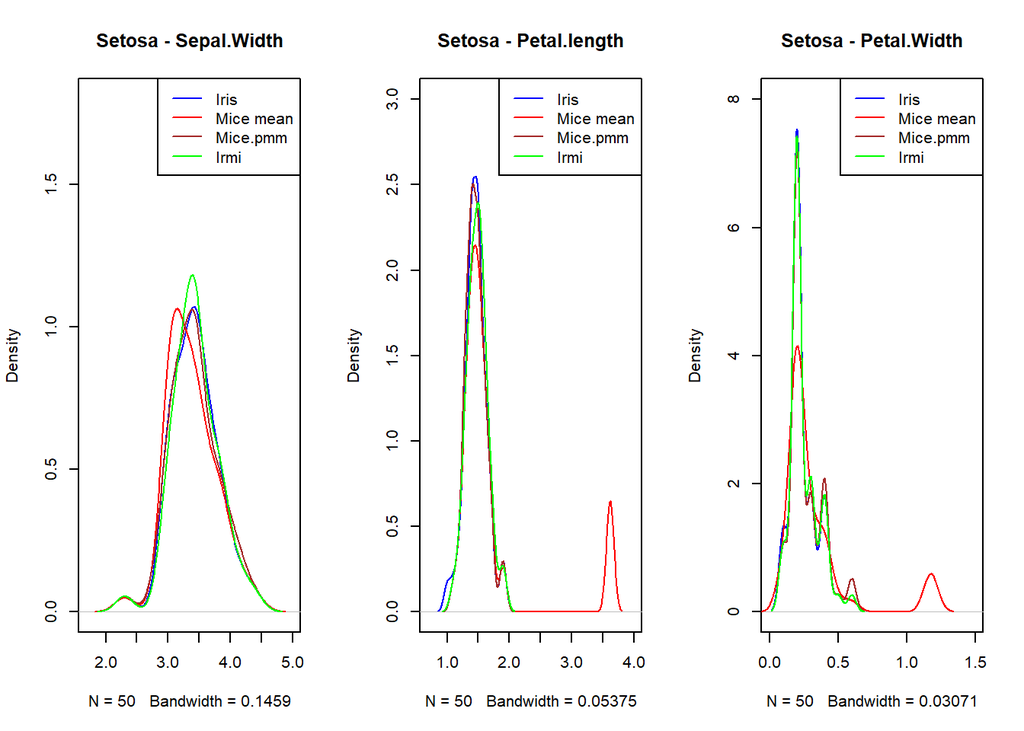

```r
### Graficamos las densidades por especie y método de imputación aplicado
par(mfrow=c(1,3))

## Setosa - Sepal.Width

plot(density(iris.setosa$Sepal.Width),col="blue",xlim=c(1.7,5),ylim=c(0,1.8),main="Setosa - Sepal.Width")
lines(density(imputed.data.mice.mean.setosa$Sepal.Width),col="red")
lines(density(imputed.data.mice.pmm.setosa$Sepal.Width),col="brown")
lines(density(imputed.data.irmi.setosa$Sepal.Width),col="green")
legend("topright", c("Iris","Mice mean","Mice.pmm","Irmi"), lty = c(1,1,1,1), col = c("blue","red","brown","green"))

## Setosa - Petal.Length

plot(density(iris.setosa$Petal.Length),col="blue",xlim=c(0.7,4),ylim=c(0,3.0),main="Setosa - Petal.length")
lines(density(imputed.data.mice.mean.setosa$Petal.Length),col="red")
lines(density(imputed.data.mice.pmm.setosa$Petal.Length),col="brown")
lines(density(imputed.data.irmi.setosa$Petal.Length),col="green")
legend("topright", c("Iris","Mice mean","Mice.pmm","Irmi"), lty = c(1,1,1,1), col = c("blue","red","brown","green"))


## Setosa - Petal.Width

plot(density(iris.setosa$Petal.Width),col="blue",xlim=c(0,1.5),ylim=c(0,8.0),main="Setosa - Petal.Width")
lines(density(imputed.data.mice.mean.setosa$Petal.Width),col="red")
lines(density(imputed.data.mice.pmm.setosa$Petal.Width),col="brown")
lines(density(imputed.data.irmi.setosa$Petal.Width),col="green")
legend("topright", c("Iris","Mice mean","Mice.pmm","Irmi"), lty = c(1,1,1,1), col = c("blue","red","brown","green"))
```

- Especie Virginica

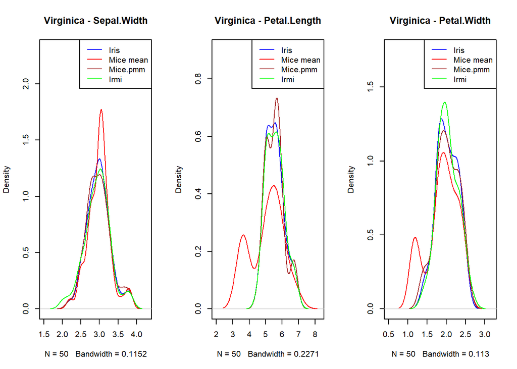

```r
## Virginica - Sepal.Width
par(mfrow=c(1,3))

plot(density(iris.virginica$Sepal.Width),col="blue",xlim=c(1.5,4.3),ylim=c(0,2.3),main="Virginica - Sepal.Width")
lines(density(imputed.data.mice.mean.virginica$Sepal.Width),col="red")
lines(density(imputed.data.mice.pmm.virginica$Sepal.Width),col="brown")
lines(density(imputed.data.irmi.virginica$Sepal.Width),col="green")
legend("topright", c("Iris","Mice mean","Mice.pmm","Irmi"), lty = c(1,1,1,1), col = c("blue","red","brown","green"))

## Virginica - Petal.Length

plot(density(iris.virginica$Petal.Length),col="blue",xlim=c(2,8.3),ylim=c(0,0.9),main="Virginica - Petal.Length")
lines(density(imputed.data.mice.mean.virginica$Petal.Length),col="red")
lines(density(imputed.data.mice.pmm.virginica$Petal.Length),col="brown")
lines(density(imputed.data.irmi.virginica$Petal.Length),col="green")
legend("topright", c("Iris","Mice mean","Mice.pmm","Irmi"), lty = c(1,1,1,1), col = c("blue","red","brown","green"))


## Virginica - Petal.Width

plot(density(iris.virginica$Petal.Width),col="blue",xlim=c(0.5,3.2),ylim=c(0,1.75),main="Virginica - Petal.Width")
lines(density(imputed.data.mice.mean.virginica$Petal.Width),col="red")
lines(density(imputed.data.mice.pmm.virginica$Petal.Width),col="brown")
lines(density(imputed.data.irmi.virginica$Petal.Width),col="green")
legend("topright", c("Iris","Mice mean","Mice.pmm","Irmi"), lty = c(1,1,1,1), col = c("blue","red","brown","green"))
```

- Especie Versicolor

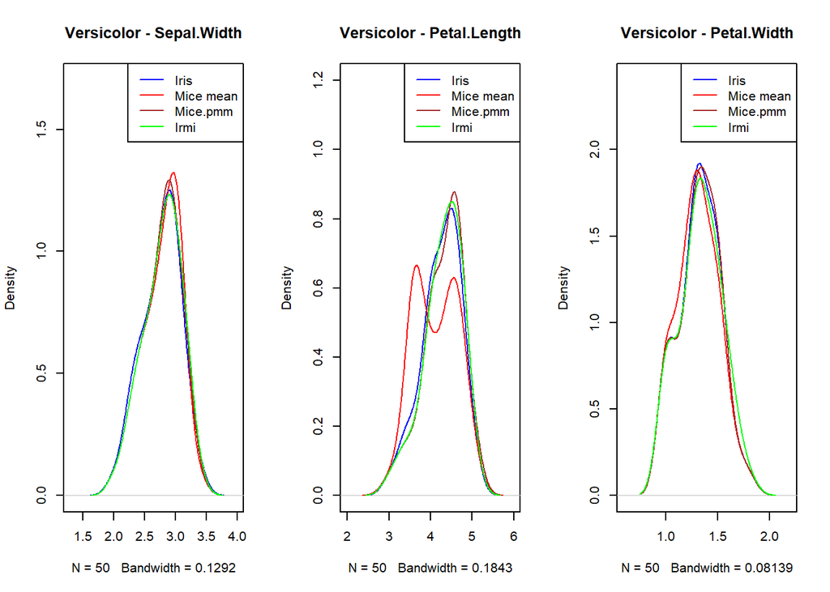

```r
## Versicolor - Sepal.Width
par(mfrow=c(1,3))

plot(density(iris.versicolor$Sepal.Width),col="blue",xlim=c(1.3,4),ylim=c(0,1.7),main="Versicolor - Sepal.Width")
lines(density(imputed.data.mice.mean.versicolor$Sepal.Width),col="red")
lines(density(imputed.data.mice.pmm.versicolor$Sepal.Width),col="brown")
lines(density(imputed.data.irmi.versicolor$Sepal.Width),col="green")
legend("topright", c("Iris","Mice mean","Mice.pmm","Irmi"), lty = c(1,1,1,1), col = c("blue","red","brown","green"))


## Versicolor - Petal.Length

plot(density(iris.versicolor$Petal.Length),col="blue",xlim=c(2,6),ylim=c(0,1.2),main="Versicolor - Petal.Length")
lines(density(imputed.data.mice.mean.versicolor$Petal.Length),col="red")
lines(density(imputed.data.mice.pmm.versicolor$Petal.Length),col="brown")
lines(density(imputed.data.irmi.versicolor$Petal.Length),col="green")
legend("topright", c("Iris","Mice mean","Mice.pmm","Irmi"), lty = c(1,1,1,1), col = c("blue","red","brown","green"))


## Versicolor - Petal.Width

plot(density(iris.versicolor$Petal.Width),col="blue",xlim=c(0.6,2.2),ylim=c(0,2.4),main="Versicolor - Petal.Width")
lines(density(imputed.data.mice.mean.versicolor$Petal.Width),col="red")
lines(density(imputed.data.mice.pmm.versicolor$Petal.Width),col="brown")
lines(density(imputed.data.irmi.versicolor$Petal.Width),col="green")
legend("topright", c("Iris","Mice mean","Mice.pmm","Irmi"), lty = c(1,1,1,1), col = c("blue","red","brown","green"))
```

Gráficamente también podemos concluir que los métodos “pmm” e “irmi” se ajustan mejor a los datos reales según especie.

# 3. Elija un conjunto de datos e incorpore en forma aleatoria datos perdidos y luego busque imputarlos. Así como en la pregunta anterior, realice un breve análisis descriptivo y haga comparaciones de las técnicas de imputaciones escogidas (elija el criterio de comparación).

## Carga de datos y descripción de las variables

De acuerdo con los criterios de la Organización Mundial de la Salud, se realizó una prueba de detección de diabetes en una población de mujeres que tenían al menos 21 años, de origen indígena pima y que vivían cerca de Phoenix, Arizona. Los datos fueron recopilados por el Instituto Nacional de Diabetes y Enfermedades Digestivas y Renales de los Estados Unidos.

```r
library(MASS)
data("Pima.tr")
head(Pima.tr)
```

```
##   npreg glu bp skin  bmi   ped age type
## 1     5  86 68   28 30.2 0.364  24   No
## 2     7 195 70   33 25.1 0.163  55  Yes
## 3     5  77 82   41 35.8 0.156  35   No
## 4     0 165 76   43 47.9 0.259  26   No
## 5     0 107 60   25 26.4 0.133  23   No
## 6     5  97 76   27 35.6 0.378  52  Yes
```

Las variables que contiene la data son:

- npreg : número de embarazos
- glu: Concentración plasmática de glucosa en una prueba oral de tolerancia a la glucosa.
- bp: Presión arterial diastólica (mm Hg).
- skin: Tríceps piel pliegue espesor (mm).
- bmi: índice de masa corporal (peso en kg / (altura en m) ^ 2).
- ped: diabetes pedigrí función
- age: edad en años
- type: Sí o No, para diabéticos según criterios de la OMS.

La data contiene 200 observaciones con 8 variables, siendo la variable type la de respuesta binaria, el resto son variables numéricas

```r
dim(Pima.tr)
```

```
## [1] 200   8
```

```r
str(Pima.tr)
```

```
## 'data.frame':    200 obs. of  8 variables:
##  $ npreg: int  5 7 5 0 0 5 3 1 3 2 ...
##  $ glu  : int  86 195 77 165 107 97 83 193 142 128 ...
##  $ bp   : int  68 70 82 76 60 76 58 50 80 78 ...
##  $ skin : int  28 33 41 43 25 27 31 16 15 37 ...
##  $ bmi  : num  30.2 25.1 35.8 47.9 26.4 35.6 34.3 25.9 32.4 43.3 ...
##  $ ped  : num  0.364 0.163 0.156 0.259 0.133 ...
##  $ age  : int  24 55 35 26 23 52 25 24 63 31 ...
##  $ type : Factor w/ 2 levels "No","Yes": 1 2 1 1 1 2 1 1 1 2 ...
```

Verificamos que la data original no contiene valores perdidos:

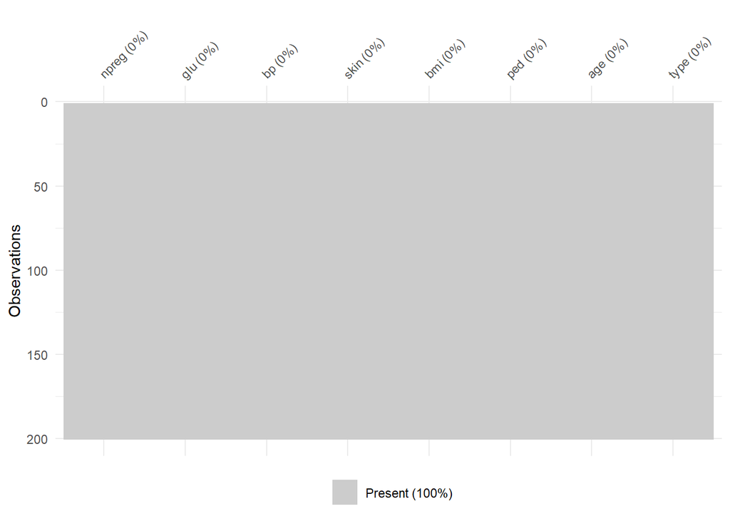

```r
vis_miss(Pima.tr)
```

Observamos que la data no contiene NA, ahora guardaremos la data original para realizar unos pequeños desciptivos y luego comparar la efectividad de las imputaciones realizadas:

```r
## Guardamos la data original
original= Pima.tr
```

## Análisis descriptivo de la data Original

Realizamos unos gráficos de densidad de las variables numérica según la variable de respuesta binaria (Tiene/No tiene diabetes). Los aleatorios que creemos y las imputaciones debería recuperarnos las densidades observadas:

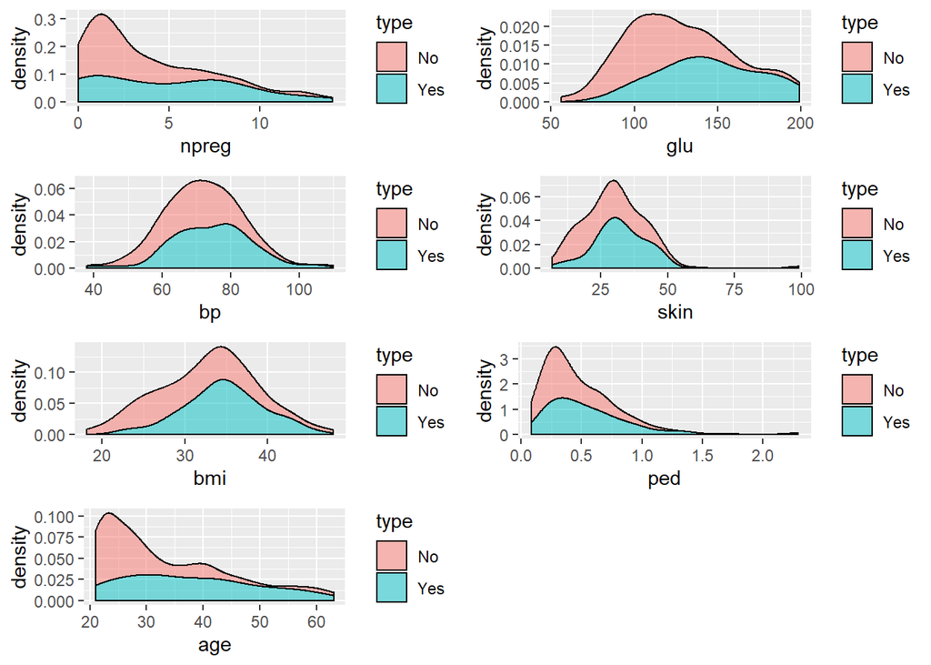

```r
p1.npreg=original %>%
          ggplot(aes(npreg, fill = type)) +
          geom_density(position = "stack",alpha=0.5)

p2.glu=original %>%
  ggplot(aes(glu, fill = type)) +
  geom_density(position = "stack",alpha=0.5)

p3.bp=original %>%
  ggplot(aes(bp, fill = type)) +
  geom_density(position = "stack",alpha=0.5)

p4.skin=original %>%
  ggplot(aes(skin, fill = type)) +
  geom_density(position = "stack",alpha=0.5)

p5.bmi=original %>%
  ggplot(aes(bmi, fill = type)) +
  geom_density(position = "stack",alpha=0.5)

p6.ped=original %>%
  ggplot(aes(ped, fill = type)) +
  geom_density(position = "stack",alpha=0.5)

p7.age=original %>%
  ggplot(aes(age, fill = type)) +
  geom_density(position = "stack",alpha=0.5)

grid.arrange(p1.npreg,p2.glu,p3.bp,p4.skin,p5.bmi,p6.ped,p7.age, nrow=4)
```

## Creación de “missing” aleatorios al data set

Creamos 10% de valores aleatorios a los registros de la base a cada una de las variables, incluyendo la variable de respuesta binaria, de la siguiente forma:

```r
set.seed(123)
missData=data.table(SimIm(Pima.tr,0.1))
names(missData)= c("npreg","glu","bp","skin","bmi","ped","age","type")
missData
```

```
##      npreg glu bp skin  bmi   ped age type
##   1:     5  86 NA   28 30.2 0.364  24    1
##   2:     7  NA 70   33 25.1 0.163  55    2
##   3:     5  77 NA   41 35.8 0.156  35    1
##   4:     0 165 76   43 47.9 0.259  26    1
##   5:    NA 107 60   25 26.4 0.133  23    1
##  ---
## 196:     2 141 58   34 25.4 0.699  24    1
## 197:     7 129 68   49 38.5 0.439  43    2
## 198:     0 106 70   37 39.4 0.605  22    1
## 199:     1 118 58   36 33.3    NA  23    1
## 200:     8  NA 62   26 34.0 0.543  46    2
```

Verificamos el número de missing creados por variable

```r
sapply(missData, function(x) sum(is.na(x)))
```

```
## npreg   glu    bp  skin   bmi   ped   age  type
##    18    21    19    16    18    13    13    19
```

## Imputación de los valores perdidos aleatorios creados

A continuación se compara 2 algoritmos (en las variables numéricas) que contiene el paquete “Mice”: “Pmm” y “rf” (Random Forest). Adicionalmente, utilizamos el método “mean”. Para la variable de respuesta binaria se utilizó “logreg.boot” (Regresión logística con bootstrap)

**Mice con algoritmo Pmm**

```r
missData[, type:=as.factor(type)]
# Mice - pmm
init = mice(missData , maxit=10)
meth = init$method
predM = init$predictorMatrix

meth[c("npreg")]="pmm"
meth[c("glu")]="pmm"
meth[c("bp")]="pmm"
meth[c("skin")]="pmm"
meth[c("bmi")]="pmm"
meth[c("ped")]="pmm"
meth[c("age")]="pmm"
meth[c("type")]="logreg.boot"

set.seed(123)
imputed.mice.pmm = mice(missData, method=meth , predictorMatrix=predM , m=5,seed = 123,diag=FALSE, print=FALSE)
imputed.data.mice.pmm= complete(imputed.mice.pmm)
```

**Mice con algoritmo Random Forest**

```r
init = mice(missData , maxit=10)
meth = init$method
predM = init$predictorMatrix

meth[c("npreg")]="rf"
meth[c("glu")]="rf"
meth[c("bp")]="rf"
meth[c("skin")]="rf"
meth[c("bmi")]="rf"
meth[c("ped")]="rf"
meth[c("age")]="rf"
meth[c("type")]="logreg.boot"

set.seed(123)
imputed.mice.rf = mice(missData, method=meth , predictorMatrix=predM , m=5,seed = 123,diag=FALSE, print=FALSE)
imputed.data.mice.rf = complete(imputed.mice.rf)
```

**Mice con Mean**

```r
init = mice(missData , maxit=10)
meth = init$method
predM = init$predictorMatrix

meth[c("npreg")]="mean"
meth[c("glu")]="mean"
meth[c("bp")]="mean"
meth[c("skin")]="mean"
meth[c("bmi")]="mean"
meth[c("ped")]="mean"
meth[c("age")]="mean"
meth[c("type")]="logreg.boot"

set.seed(123)
imputed.mice.mean = mice(missData, method=meth , predictorMatrix=predM , m=5,seed = 123,diag=FALSE, print=FALSE)
imputed.data.mice.mean= complete(imputed.mice.mean)
```

## Vericación de las medias de las variables numéricas imputadas

```r
medias.original=original %>%
  group_by(type) %>%
  summarise(mean.npreg=mean(npreg),
            mean.glu=mean(glu),
            mean.bp=mean(bp),
            mean.skin=mean(skin),
            mean.bmi=mean(bmi),
            mean.ped=mean(ped),
            mean.age=mean(age))

medias.mice.rf=imputed.data.mice.rf %>%
  group_by(type) %>%
  summarise(mean.npreg=mean(npreg),
            mean.glu=mean(glu),
            mean.bp=mean(bp),
            mean.skin=mean(skin),
            mean.bmi=mean(bmi),
            mean.ped=mean(ped),
            mean.age=mean(age))

medias.mice.pmm=imputed.data.mice.pmm %>%
  group_by(type) %>%
  summarise(mean.npreg=mean(npreg),
            mean.glu=mean(glu),
            mean.bp=mean(bp),
            mean.skin=mean(skin),
            mean.bmi=mean(bmi),
            mean.ped=mean(ped),
            mean.age=mean(age))

medias.mice.mean=imputed.data.mice.mean %>%
  group_by(type) %>%
  summarise(mean.npreg=mean(npreg),
            mean.glu=mean(glu),
            mean.bp=mean(bp),
            mean.skin=mean(skin),
            mean.bmi=mean(bmi),
            mean.ped=mean(ped),
            mean.age=mean(age))

list(medias.original=data.frame(medias.original),
     medias.mice.rf=data.frame(medias.mice.rf),
     medias.mice.pmm=data.frame(medias.mice.pmm),
     medias.mice.mean=data.frame(medias.mice.mean))
```

```
## $medias.original
##   type mean.npreg mean.glu  mean.bp mean.skin mean.bmi  mean.ped mean.age
## 1   No   2.916667 113.1061 69.54545  27.20455 31.07424 0.4154848 29.23485
## 2  Yes   4.838235 145.0588 74.58824  33.11765 34.70882 0.5486618 37.69118
##
## $medias.mice.rf
##   type mean.npreg mean.glu  mean.bp mean.skin mean.bmi  mean.ped mean.age
## 1    1   2.977099 112.4733 69.68702  27.25191 31.35954 0.4276870 29.63359
## 2    2   4.840580 139.9275 73.89855  33.81159 34.75652 0.5434348 36.52174
##
## $medias.mice.pmm
##   type mean.npreg mean.glu  mean.bp mean.skin mean.bmi  mean.ped mean.age
## 1    1   2.962121 113.0455 69.68182  27.42424 31.32197 0.4201591 29.47727
## 2    2   5.117647 143.1912 74.61765  33.85294 34.28235 0.6124118 37.05882
##
## $medias.mice.mean
##   type mean.npreg mean.glu  mean.bp mean.skin mean.bmi  mean.ped mean.age
## 1    1   2.999832 114.7190 69.83109  27.14998 31.32416 0.4296458 29.46859
## 2    2   5.102564 139.1753 74.22812  34.00890 34.56516 0.5299981 36.93002
```

```r
#### RMSE normalizado

Rmse.mice.rf=Rmse(imputed.data.mice.rf[,1:7],as.data.frame(missData)[,1:7], original[,1:7], norm = TRUE)

Rmse.mice.pmm=Rmse(imputed.data.mice.pmm[,1:7],as.data.frame(missData)[,1:7], original[,1:7], norm = TRUE)

Rmse.mice.mean=Rmse(imputed.data.mice.mean[,1:7],as.data.frame(missData)[,1:7], original[,1:7], norm = TRUE)

Rmse.com=data.table(Rmse.mice.rf=Rmse.mice.rf, Rmse.mice.pmm=Rmse.mice.pmm, Rmse.mice.mean=Rmse.mice.mean)
Rmse.com
```

```
##    Rmse.mice.rf Rmse.mice.pmm Rmse.mice.mean
## 1:    0.4714094     0.3829313      0.3679586
```

Con éste indicador, podemos comprobar lo indicado en el párrafo anterior. A pesar que el algotirmo “rf” es más robusto que el método “mean”; sin embargo, observaremos visualmente qué tanto impacto tienen según variable de respuesta.

**Gráficos de densidad de los métodos de imputación utilizados**

Se han realizado gráficos de densidad de las variables imputadas según la variable de respuesta binaria y se obsevará las diferencias obtenidas por cada método de imputación aplicado:

- Type=Yes

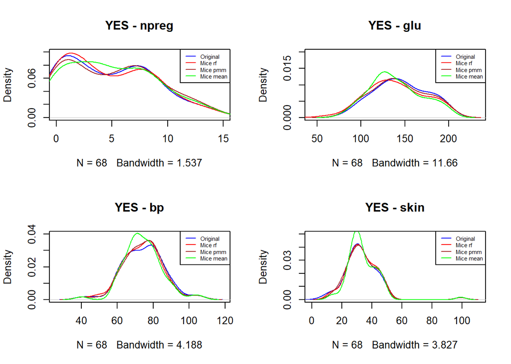

```r
### Graficamente por la Clase "Yes"/"No"

original=data.table(original)
imputed.data.mice.rf=data.table(imputed.data.mice.rf)
imputed.data.mice.pmm=data.table(imputed.data.mice.pmm)
imputed.data.mice.mean=data.table(imputed.data.mice.mean)

### Graficamos las densidades por especie y método de imputación aplicado
par(mfrow=c(2,2))

## YES - npreg
plot(density(original[type=="Yes",]$npreg),col="blue",xlim=c(0,15.0),ylim=c(0,0.1),main="YES - npreg")
lines(density(imputed.data.mice.rf[type=="2",]$npreg),col="red")
lines(density(imputed.data.mice.pmm[type=="2",]$npreg),col="brown")
lines(density(imputed.data.mice.mean[type=="2",]$npreg),col="green")
legend("topright", c("Original","Mice rf","Mice pmm","Mice mean"),
       lty =c(1,1,1,1), col = c("blue","red","brown","green"), cex = 0.55)

## YES - glu
plot(density(original[type=="Yes",]$glu),col="blue",xlim=c(44,234),ylim=c(0,0.02),main="YES - glu")
lines(density(imputed.data.mice.rf[type=="2",]$glu),col="red")
lines(density(imputed.data.mice.pmm[type=="2",]$glu),col="brown")
lines(density(imputed.data.mice.mean[type=="2",]$glu),col="green")
legend("topright", c("Original","Mice rf","Mice pmm","Mice mean"),
       lty = c(1,1,1,1), col = c("blue","red","brown","green"), cex = 0.55)

## YES - bp
plot(density(original[type=="Yes",]$bp),col="blue",xlim=c(26,119),ylim=c(0,0.04),main="YES - bp")
lines(density(imputed.data.mice.rf[type=="2",]$bp),col="red")
lines(density(imputed.data.mice.pmm[type=="2",]$bp),col="brown")
lines(density(imputed.data.mice.mean[type=="2",]$bp),col="green")
legend("topright", c("Original","Mice rf","Mice pmm","Mice mean"),
       lty = c(1,1,1,1), col = c("blue","red","brown","green"), cex = 0.55)


## YES - skin
plot(density(original[type=="Yes",]$skin),col="blue",xlim=c(0,111),ylim=c(0,0.05),main="YES - skin")
lines(density(imputed.data.mice.rf[type=="2",]$skin),col="red")
lines(density(imputed.data.mice.pmm[type=="2",]$skin),col="brown")
lines(density(imputed.data.mice.mean[type=="2",]$skin),col="green")
legend("topright", c("Original","Mice rf","Mice pmm","Mice mean"),
       lty = c(1,1,1,1), col = c("blue","red","brown","green"), cex = 0.55)
```

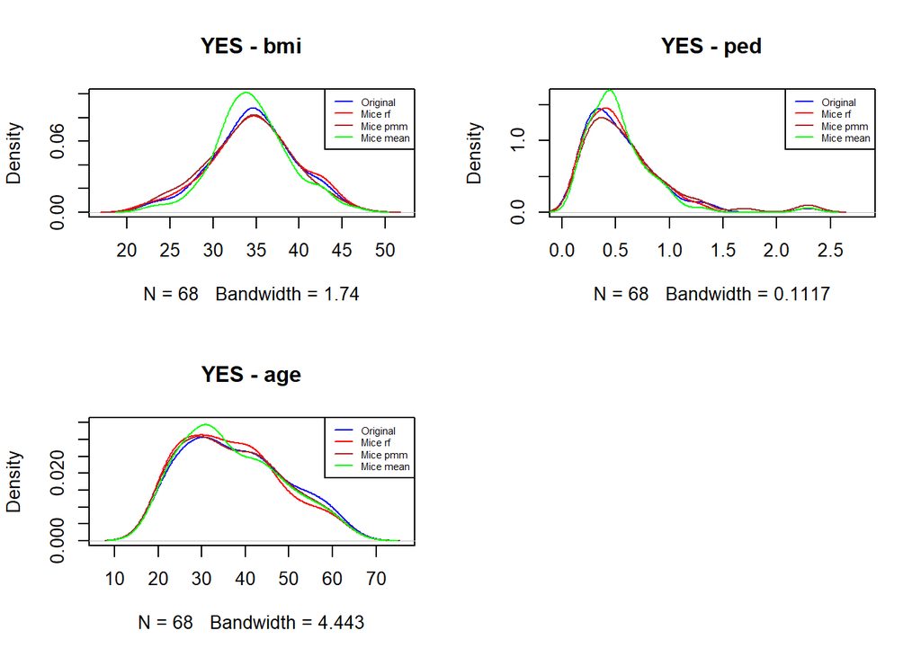

```r
par(mfrow=c(2,2))

## YES - bmi
plot(density(original[type=="Yes",]$bmi),col="blue",xlim=c(17,52),ylim=c(0,0.1),main="YES - bmi")
lines(density(imputed.data.mice.rf[type=="2",]$bmi),col="red")
lines(density(imputed.data.mice.pmm[type=="2",]$bmi),col="brown")
lines(density(imputed.data.mice.mean[type=="2",]$bmi),col="green")
legend("topright", c("Original","Mice rf","Mice pmm","Mice mean"),
       lty = c(1,1,1,1), col = c("blue","red","brown","green"), cex = 0.55)


## YES - ped
plot(density(original[type=="Yes",]$ped),col="blue",xlim=c(0,2.8),ylim=c(0,1.65),main="YES - ped")
lines(density(imputed.data.mice.rf[type=="2",]$ped),col="red")
lines(density(imputed.data.mice.pmm[type=="2",]$ped),col="brown")
lines(density(imputed.data.mice.mean[type=="2",]$ped),col="green")
legend("topright", c("Original","Mice rf","Mice pmm","Mice mean"),
       lty = c(1,1,1,1), col = c("blue","red","brown","green"), cex = 0.55)


## YES - age
plot(density(original[type=="Yes",]$age),col="blue",xlim=c(7,76),ylim=c(0,0.035),main="YES - age")
lines(density(imputed.data.mice.rf[type=="2",]$age),col="red")
lines(density(imputed.data.mice.pmm[type=="2",]$age),col="brown")
lines(density(imputed.data.mice.mean[type=="2",]$age),col="green")
legend("topright", c("Original","Mice rf","Mice pmm","Mice mean"),
       lty = c(1,1,1,1), col = c("blue","red","brown","green"), cex = 0.55)
```

- Type=No

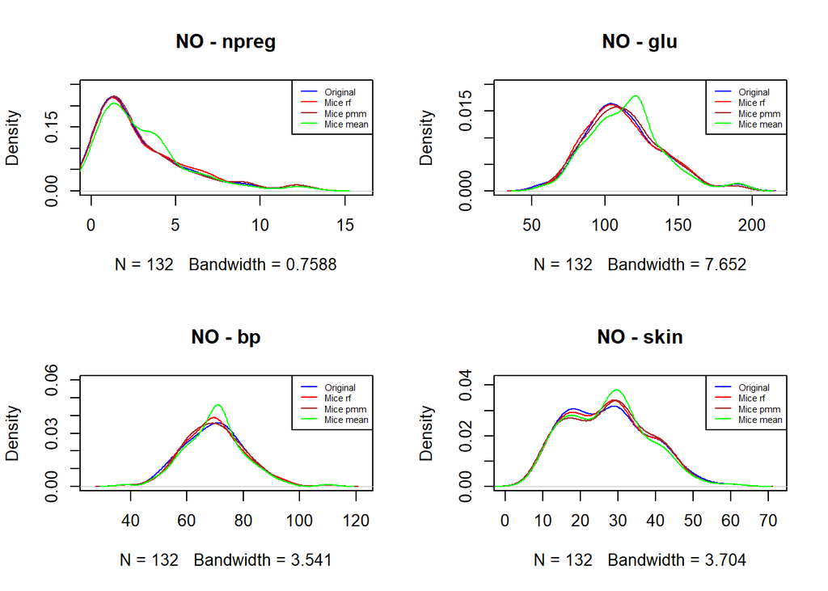

```r
par(mfrow=c(2,2))

## No - npreg
plot(density(original[type=="No",]$npreg),col="blue",xlim=c(0,16),ylim=c(0,0.25),main="NO - npreg")
lines(density(imputed.data.mice.rf[type=="1",]$npreg),col="red")
lines(density(imputed.data.mice.pmm[type=="1",]$npreg),col="brown")
lines(density(imputed.data.mice.mean[type=="1",]$npreg),col="green")
legend("topright", c("Original","Mice rf","Mice pmm","Mice mean"),
       lty = c(1,1,1,1), col = c("blue","red","brown","green"), cex = 0.55)

## No - glu
plot(density(original[type=="No",]$glu),col="blue",xlim=c(32,216),ylim=c(0,0.02),main="NO - glu")
lines(density(imputed.data.mice.rf[type=="1",]$glu),col="red")
lines(density(imputed.data.mice.pmm[type=="1",]$glu),col="brown")
lines(density(imputed.data.mice.mean[type=="1",]$glu),col="green")
legend("topright", c("Original","Mice rf","Mice pmm","Mice mean"),
       lty = c(1,1,1,1), col = c("blue","red","brown","green"), cex = 0.55)

## No - bp
plot(density(original[type=="No",]$bp),col="blue",xlim=c(26,122),ylim=c(0,0.06),main="NO - bp")
lines(density(imputed.data.mice.rf[type=="1",]$bp),col="red")
lines(density(imputed.data.mice.pmm[type=="1",]$bp),col="brown")
lines(density(imputed.data.mice.mean[type=="1",]$bp),col="green")
legend("topright", c("Original","Mice rf","Mice pmm","Mice mean"),
       lty = c(1,1,1,1), col = c("blue","red","brown","green"), cex = 0.55)


## No - skin
plot(density(original[type=="No",]$skin),col="blue",xlim=c(0,72),ylim=c(0,0.042),main="NO - skin")
lines(density(imputed.data.mice.rf[type=="1",]$skin),col="red")
lines(density(imputed.data.mice.pmm[type=="1",]$skin),col="brown")
lines(density(imputed.data.mice.mean[type=="1",]$skin),col="green")
legend("topright", c("Original","Mice rf","Mice pmm","Mice mean"),
       lty = c(1,1,1,1), col = c("blue","red","brown","green"), cex = 0.55)
```

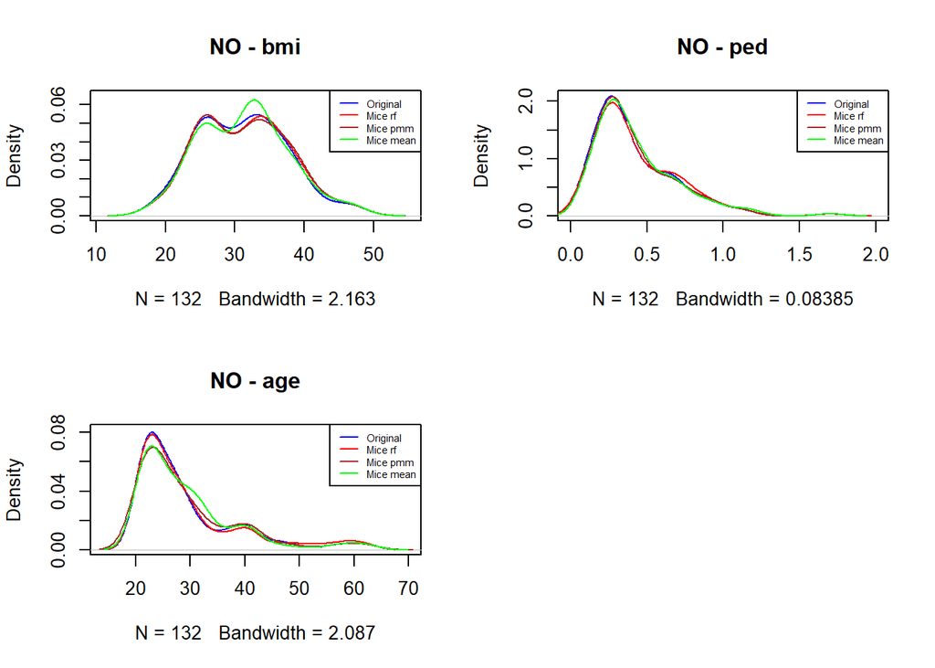

```r
par(mfrow=c(2,2))

## No - bmi
plot(density(original[type=="No",]$bmi),col="blue",xlim=c(11,55),ylim=c(0,0.065),main="NO - bmi")
lines(density(imputed.data.mice.rf[type=="1",]$bmi),col="red")
lines(density(imputed.data.mice.pmm[type=="1",]$bmi),col="brown")
lines(density(imputed.data.mice.mean[type=="1",]$bmi),col="green")
legend("topright", c("Original","Mice rf","Mice pmm","Mice mean"),
       lty = c(1,1,1,1), col = c("blue","red","brown","green"), cex = 0.55)


## No - ped
plot(density(original[type=="No",]$ped),col="blue",xlim=c(0,2.0),ylim=c(0,2.1),main="NO - ped")
lines(density(imputed.data.mice.rf[type=="1",]$ped),col="red")
lines(density(imputed.data.mice.pmm[type=="1",]$ped),col="brown")
lines(density(imputed.data.mice.mean[type=="1",]$ped),col="green")
legend("topright", c("Original","Mice rf","Mice pmm","Mice mean"),
       lty = c(1,1,1,1), col = c("blue","red","brown","green"), cex = 0.55)


## No - age
plot(density(original[type=="No",]$age),col="blue",xlim=c(14,70),ylim=c(0,0.082),main="NO - age")
lines(density(imputed.data.mice.rf[type=="1",]$age),col="red")
lines(density(imputed.data.mice.pmm[type=="1",]$age),col="brown")
lines(density(imputed.data.mice.mean[type=="1",]$age),col="green")
legend("topright", c("Original","Mice rf","Mice pmm","Mice mean"),
       lty = c(1,1,1,1), col = c("blue","red","brown","green"), cex = 0.55)
```

A pesar que de acuerdo al RMSE, parecen haber diferencias entre los métodos imputados, en los gráficos de densidad se observa que las diferencias entre métodos no es drástica.

# 4. Considere el conjunto de datos msleep del paquete ggplot2. Realice un análisis descriptivo, aplique las técnicas de imputaciones de los paquetes mostrados en clase u otros que considere conveniente.

## Carga de los datos

La data contiene 11 variables catergóricas y númericas de 83 observaciones.

```r
data("msleep",package = "ggplot2")
msleep=data.table(msleep)
dim(msleep)
```

```
## [1] 83 11
```

```r
summary(msleep)
```

```
##      name              genus               vore
##  Length:83          Length:83          Length:83
##  Class :character   Class :character   Class :character
##  Mode  :character   Mode  :character   Mode  :character
##
##
##
##
##     order           conservation        sleep_total      sleep_rem
##  Length:83          Length:83          Min.   : 1.90   Min.   :0.100
##  Class :character   Class :character   1st Qu.: 7.85   1st Qu.:0.900
##  Mode  :character   Mode  :character   Median :10.10   Median :1.500
##                                        Mean   :10.43   Mean   :1.875
##                                        3rd Qu.:13.75   3rd Qu.:2.400
##                                        Max.   :19.90   Max.   :6.600
##                                                        NA's   :22
##   sleep_cycle         awake          brainwt            bodywt
##  Min.   :0.1167   Min.   : 4.10   Min.   :0.00014   Min.   :   0.005
##  1st Qu.:0.1833   1st Qu.:10.25   1st Qu.:0.00290   1st Qu.:   0.174
##  Median :0.3333   Median :13.90   Median :0.01240   Median :   1.670
##  Mean   :0.4396   Mean   :13.57   Mean   :0.28158   Mean   : 166.136
##  3rd Qu.:0.5792   3rd Qu.:16.15   3rd Qu.:0.12550   3rd Qu.:  41.750
##  Max.   :1.5000   Max.   :22.10   Max.   :5.71200   Max.   :6654.000
##  NA's   :51                       NA's   :27
```

## Verificación de valores perdidos

```r
sapply(msleep, function(x) sum(is.na(x)))
```

```
##         name        genus         vore        order conservation
##            0            0            7            0           29
##  sleep_total    sleep_rem  sleep_cycle        awake      brainwt
##            0           22           51            0           27
##       bodywt
##            0
```

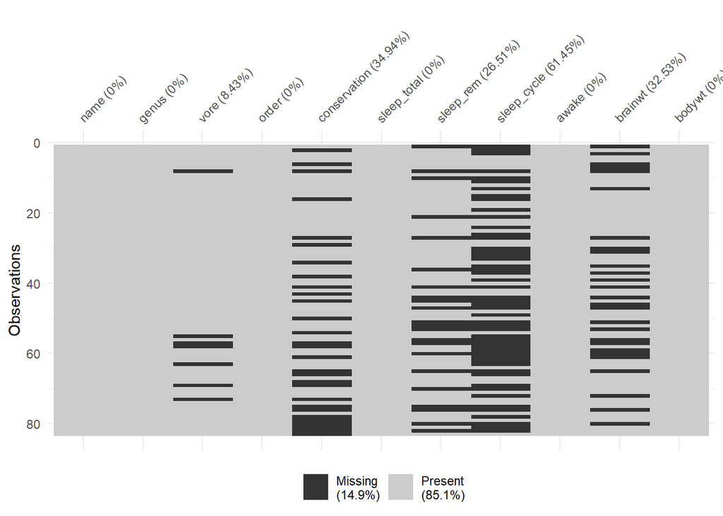

```r
vis_miss(msleep)
```

Se observa que 5 de 11 variables tienen valores perdidos.Las variables que contienen valores perdidos son:

- Vore : 8.43%
- Conservatio: 34.94%
- Sleep_rem: 26.51%
- spleep_cycle: 61.45%
- brainwt: 32.53%

En general, la data tiene el 14.9% de los registros con valores perdidos. A continuación, se presenta las relaciones de los registros en missing con las 5 variables que las contienen:

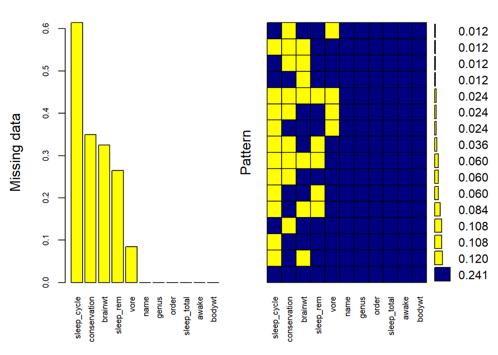

```
##
##  Variables sorted by number of missings:
##      Variable      Count
##   sleep_cycle 0.61445783
##  conservation 0.34939759
##       brainwt 0.32530120
##     sleep_rem 0.26506024
##          vore 0.08433735
##          name 0.00000000
##         genus 0.00000000
##         order 0.00000000
##   sleep_total 0.00000000
##         awake 0.00000000
##        bodywt 0.00000000
```

```r
# Otro
mice_plot <- aggr(msleep, col=c('navyblue','yellow'),
                  numbers=TRUE, sortVars=TRUE,
                  labels=names(msleep), cex.axis=.7,
                  gap=3, ylab=c("Missing data","Pattern"))
```

## Análisis descriptivo

Antes de empezar con el análisis descriptivo, se modifica las variables que son tipo “character” a “factor”:

```r
## Estructura de la base de datos
str(msleep)
```

```
## Classes 'data.table' and 'data.frame':   83 obs. of  11 variables:
##  $ name        : chr  "Cheetah" "Owl monkey" "Mountain beaver" "Greater short-tailed shrew" ...
##  $ genus       : chr  "Acinonyx" "Aotus" "Aplodontia" "Blarina" ...
##  $ vore        : chr  "carni" "omni" "herbi" "omni" ...
##  $ order       : chr  "Carnivora" "Primates" "Rodentia" "Soricomorpha" ...
##  $ conservation: chr  "lc" NA "nt" "lc" ...
##  $ sleep_total : num  12.1 17 14.4 14.9 4 14.4 8.7 7 10.1 3 ...
##  $ sleep_rem   : num  NA 1.8 2.4 2.3 0.7 2.2 1.4 NA 2.9 NA ...
##  $ sleep_cycle : num  NA NA NA 0.133 0.667 ...
##  $ awake       : num  11.9 7 9.6 9.1 20 9.6 15.3 17 13.9 21 ...
##  $ brainwt     : num  NA 0.0155 NA 0.00029 0.423 NA NA NA 0.07 0.0982 ...
##  $ bodywt      : num  50 0.48 1.35 0.019 600 ...
##  - attr(*, ".internal.selfref")=<externalptr>
```

```r
# cambiemos los character a factor
msleep[,name:= as.factor(name)]
msleep[,genus:= as.factor(genus)]
msleep[,vore:= as.factor(vore)]
msleep[,order:= as.factor(order)]
msleep[,conservation:= as.factor(conservation)]
str(msleep)
```

```
## Classes 'data.table' and 'data.frame':   83 obs. of  11 variables:
##  $ name        : Factor w/ 83 levels "African elephant",..: 12 57 52 36 17 77 55 81 21 67 ...
##  $ genus       : Factor w/ 77 levels "Acinonyx","Aotus",..: 1 2 3 4 5 6 7 8 9 10 ...
##  $ vore        : Factor w/ 4 levels "carni","herbi",..: 1 4 2 4 2 2 1 NA 1 2 ...
##  $ order       : Factor w/ 19 levels "Afrosoricida",..: 3 15 17 19 2 14 3 17 3 2 ...
##  $ conservation: Factor w/ 6 levels "cd","domesticated",..: 4 NA 5 4 2 NA 6 NA 2 4 ...
##  $ sleep_total : num  12.1 17 14.4 14.9 4 14.4 8.7 7 10.1 3 ...
##  $ sleep_rem   : num  NA 1.8 2.4 2.3 0.7 2.2 1.4 NA 2.9 NA ...
##  $ sleep_cycle : num  NA NA NA 0.133 0.667 ...
##  $ awake       : num  11.9 7 9.6 9.1 20 9.6 15.3 17 13.9 21 ...
##  $ brainwt     : num  NA 0.0155 NA 0.00029 0.423 NA NA NA 0.07 0.0982 ...
##  $ bodywt      : num  50 0.48 1.35 0.019 600 ...
##  - attr(*, ".internal.selfref")=<externalptr>
```

**Gráficos de boxplot de las variables según “Sleep Total”**

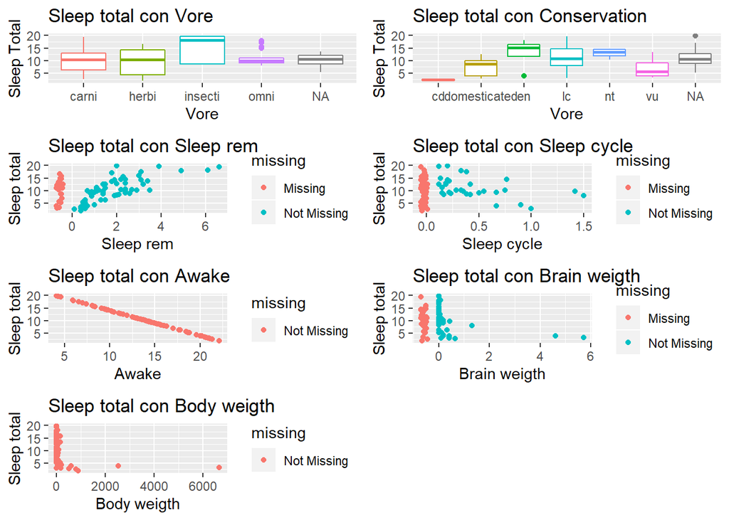

```r
# Gráfico boxplot de Vore con Sleep Total

p1=msleep %>%
  ggplot(aes(vore,sleep_total,color=vore)) +
  geom_boxplot() +
  theme(legend.position = "none") +
  labs(y = "Sleep Total", x = "Vore") +
  ggtitle("Sleep total con Vore")

# Gráfico boxplot de Conservation con Sleep Total

p2=msleep %>%
  ggplot(aes(conservation,sleep_total,color=conservation)) +
  geom_boxplot() +
  theme(legend.position = "none") +
  labs(y = "Sleep Total", x = "Vore") +
  ggtitle("Sleep total con Conservation")

# Sleep rem con Sleep total

p3=msleep %>%
  ggplot(aes(sleep_rem, sleep_total)) +
  geom_miss_point()+
  labs(x = "Sleep rem", y = "Sleep total") +
  ggtitle("Sleep total con Sleep rem")

# Sleep cycle con Sleep total

p4=msleep %>%
  ggplot(aes(sleep_cycle, sleep_total)) +
  geom_miss_point()+
  labs(x = "Sleep cycle", y = "Sleep total") +
  ggtitle("Sleep total con Sleep cycle")

# Awake con Sleep total

p5=msleep %>%
  ggplot(aes(awake, sleep_total)) +
  geom_miss_point()+
  labs(x = "Awake", y = "Sleep total") +
  ggtitle("Sleep total con Awake")

# Brainwt con Sleep total

p6=msleep %>%
  ggplot(aes(brainwt, sleep_total)) +
  geom_miss_point()+
  labs(x = "Brain weigth", y = "Sleep total") +
  ggtitle("Sleep total con Brain weigth")

# bodywt con Sleep total

p7=msleep %>%
  ggplot(aes(bodywt, sleep_total)) +
  geom_miss_point()+
  labs(x = "Body weigth", y = "Sleep total") +
  ggtitle("Sleep total con Body weigth")


grid.arrange(p1,p2,p3,p4,p5,p6,p7,nrow=4)
```

El movimiento de los ojos al dormir “rem_sleep” y “sleep_total” tienen correlación positiva que indica que a mayor duración del sueño mayor movimiento de los ojos. La correlación negativa de -1 entre sleep_total y awake indica indica que los datos en esas dos columnas están bien registrados ya que las dos variables son complementarias. La correlación entre log(“bodywt”) y “sleep_total” es negativa indicando que a mayor peso menores horas de sueño; de igual forma a mayor peso del cerebro “brainwt” menos horas de sueño. El peso del cuerpo “bodywt” está relacionado con el peso del cerebro “brainwt”.

**Cuadro de medias de variables antes de la imputación**

A continuación se presenta las medias de las variables numéricas según “Vore” y “Conservation” y además las medias de las 3 variables numéricas que contienen missing:

```r
descrip1=data.frame(msleep %>%
  filter(is.na(vore)==FALSE) %>%
  group_by(vore) %>%
  summarise(mean.sleep.total=mean(sleep_total),
            mean.sleep.rem=mean(sleep_rem,na.rm=TRUE),
            mean.sleep.cycle=mean(sleep_cycle,na.rm = TRUE),
            mean.brain.wt=mean(brainwt,na.rm = TRUE),
            mean.awake=mean(awake),
            mean.body.wt=mean(bodywt)))

descrip2=data.frame(msleep %>%
  filter(is.na(conservation)==FALSE) %>%
  group_by(conservation) %>%
  summarise(mean.sleep.total=mean(sleep_total),
            mean.sleep.rem=mean(sleep_rem,na.rm=TRUE),
            mean.sleep.cycle=mean(sleep_cycle,na.rm = TRUE),
            mean.brain.wt=mean(brainwt,na.rm = TRUE),
            mean.awake=mean(awake),
            mean.body.wt=mean(bodywt)))

descrip3=msleep %>%
  summarise(mean.sleep.rem=mean(sleep_rem,na.rm=TRUE),
            mean.sleep.cycle=mean(sleep_cycle,na.rm = TRUE),
            mean.brain.wt=mean(brainwt,na.rm = TRUE))

descrip1; descrip2; descrip3
```

```
##      vore mean.sleep.total mean.sleep.rem mean.sleep.cycle mean.brain.wt
## 1   carni        10.378947       2.290000        0.3733333    0.07925556
## 2   herbi         9.509375       1.366667        0.4180556    0.62159750
## 3 insecti        14.940000       3.525000        0.1611111    0.02155000
## 4    omni        10.925000       1.955556        0.5924242    0.14573118
##   mean.awake mean.body.wt
## 1   13.62632     90.75111
## 2   14.49062    366.87725
## 3    9.06000     12.92160
## 4   13.07500     12.71800
```

```
##   conservation mean.sleep.total mean.sleep.rem mean.sleep.cycle
## 1           cd         2.300000       0.250000              NaN
## 2 domesticated         7.580000       1.400000        0.4583333
## 3           en        13.025000       4.600000        0.2000000
## 4           lc        11.437037       2.263636        0.2185185
## 5           nt        12.975000       1.900000        0.1833333
## 6           vu         6.928571       0.925000        0.6416667
##   mean.brain.wt mean.awake mean.body.wt
## 1           NaN   21.72500   849.997500
## 2    0.19716000   16.42000   147.069800
## 3    1.56166667   10.97500   692.421000
## 4    0.03875263   12.56296     8.045704
## 5    0.07870000   11.02500    25.409500
## 6    2.94050000   17.07857  1026.334286
```

```
##   mean.sleep.rem mean.sleep.cycle mean.brain.wt
## 1        1.87541        0.4395833     0.2815814
```

## Imputación

Se realizan las imputaciones utlizando los paquetes VIM y mice. En el caso de VIM se utilizó el método kNN para imputar las variables categóricas y robust para las numéricas.

```r
#VIM - Knn
imp4.1.1 <- kNN(msleep,k=10)
data4.imp4.1.1<-cbind(imp4.1.1[1:5],msleep[,6:11],imp4.1.1[12:22])
imp4.1.2 <- irmi(data4.imp4.1.1[,6:11],eps=10,maxit=10, robust=TRUE)
imp.data.knn<-cbind(imp4.1.1[1:5],imp4.1.2[,1:6],imp4.1.1[12:22],imp4.1.2[7:9])

#Mice
init = mice(msleep , maxit=0)
meth = init$method
predM = init$predictorMatrix

meth[c("vore")]="polyreg"
meth[c("conservation")]="polyreg"
meth[c("sleep_rem")]="pmm"
meth[c("sleep_cycle")]="pmm"
meth[c("brainwt")]="rf"

imp.mice = mice(msleep, method=meth , predictorMatrix=predM , m=5,maxit = 5,seed = 123,print=FALSE)
```

**Evaluación de imputaciones**

En el striplot de abajo se observa que los datos imputados se alinean a los datos originales con el paquete mice.

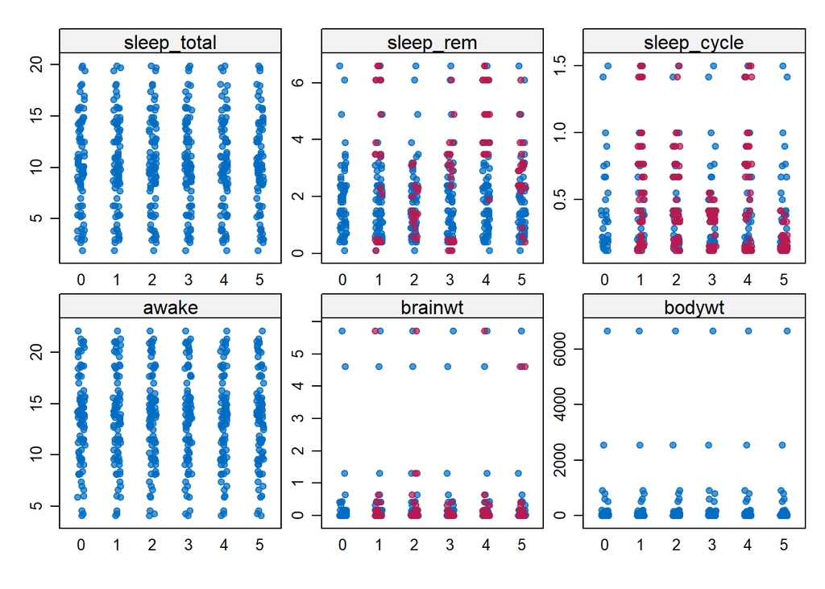

```r
library(lattice)
stripplot(imp.mice, pch = 20, cex = 1)
```

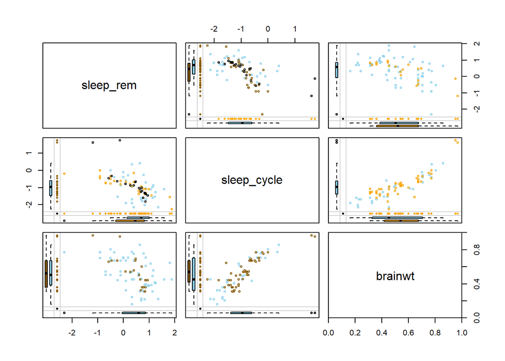

```r
library(VIM)
library(gridExtra)
vars<-c("sleep_cycle","brainwt","sleep_rem","sleep_cycle_imp","brainwt_imp","sleep_rem_imp")
data4.imp.g<-imp.data.knn[,c(7,8,10,17:19)]
data4.imp.g<-cbind(log(data4.imp.g[,c(1:3)]),imp.data.knn[,17:19])
# Building marginplot matrix
marginmatrix(data4.imp.g,
              delimiter = "_imp",
              alpha=0.9,
             size = 5)
```

**Comparación de medias de las variables con imputación y sin imputación**

Se realiza una verificación adicional de las imputaciones con las medias de las variables numéricas imputadas clasificadas por “vore” y “conservation”. Se espera que mantengan consistencia con la data original; es decir se analiza si las imputaciones de las variables categóricas no modifican las distribuciones de las variables numéricas. En la parte inferior se muestran los resultados.

```r
imp.data.knn=imp.data.knn[,1:11]
# Medias con variables imputadas con kNN e irmi
descrip1.imp=data.frame(imp.data.knn %>%
                          group_by(vore) %>%
                          summarise(mean.sleep.total=mean(sleep_total),
                                    mean.sleep.rem=mean(sleep_rem,na.rm=TRUE),
                                    mean.sleep.cycle=mean(sleep_cycle,na.rm = TRUE),
                                    mean.brain.wt=mean(brainwt,na.rm = TRUE),
                                    mean.awake=mean(awake),
                                    mean.body.wt=mean(bodywt)))

descrip2.imp=data.frame(imp.data.knn %>%
                          group_by(conservation) %>%
                          summarise(mean.sleep.total=mean(sleep_total),
                                    mean.sleep.rem=mean(sleep_rem,na.rm=TRUE),
                                    mean.sleep.cycle=mean(sleep_cycle,na.rm = TRUE),
                                    mean.brain.wt=mean(brainwt,na.rm = TRUE),
                                    mean.awake=mean(awake),
                                    mean.body.wt=mean(bodywt)))

descrip3.imp=imp.data.knn %>%
  summarise(mean.sleep.rem=mean(sleep_rem,na.rm=TRUE),
            mean.sleep.cycle=mean(sleep_cycle,na.rm = TRUE),
            mean.brain.wt=mean(brainwt,na.rm = TRUE))
```

```r
imp.data.mice= mice::complete(imp.mice)

descrip1.imp.mice=data.frame(imp.data.mice %>%
                          group_by(vore) %>%
                          summarise(mean.sleep.total=mean(sleep_total),
                                    mean.sleep.rem=mean(sleep_rem,na.rm=TRUE),
                                    mean.sleep.cycle=mean(sleep_cycle,na.rm = TRUE),
                                    mean.brain.wt=mean(brainwt,na.rm = TRUE),
                                    mean.awake=mean(awake),
                                    mean.body.wt=mean(bodywt)))

descrip2.imp.mice=data.frame(imp.data.mice %>%
                          group_by(conservation) %>%
                          summarise(mean.sleep.total=mean(sleep_total),
                                    mean.sleep.rem=mean(sleep_rem,na.rm=TRUE),
                                    mean.sleep.cycle=mean(sleep_cycle,na.rm = TRUE),
                                    mean.brain.wt=mean(brainwt,na.rm = TRUE),
                                    mean.awake=mean(awake),
                                    mean.body.wt=mean(bodywt)))


descrip3.imp.mice=imp.data.mice %>%
  summarise(mean.sleep.rem=mean(sleep_rem,na.rm=TRUE),
            mean.sleep.cycle=mean(sleep_cycle,na.rm = TRUE),
            mean.brain.wt=mean(brainwt,na.rm = TRUE))
```

```r
list(sin_imputar=descrip1,imputados_irmi=descrip1.imp,imputados_mice=descrip1.imp.mice)
```

```
## $sin_imputar
##      vore mean.sleep.total mean.sleep.rem mean.sleep.cycle mean.brain.wt
## 1   carni        10.378947       2.290000        0.3733333    0.07925556
## 2   herbi         9.509375       1.366667        0.4180556    0.62159750
## 3 insecti        14.940000       3.525000        0.1611111    0.02155000
## 4    omni        10.925000       1.955556        0.5924242    0.14573118
##   mean.awake mean.body.wt
## 1   13.62632     90.75111
## 2   14.49062    366.87725
## 3    9.06000     12.92160
## 4   13.07500     12.71800
##
## $imputados_irmi
##      vore mean.sleep.total mean.sleep.rem mean.sleep.cycle mean.brain.wt
## 1   carni        10.271429       1.981796        0.4276983    0.07558345
## 2   herbi         9.485294       1.434185        0.7225422    0.39667607
## 3 insecti        14.940000       3.120299        0.2227395    0.02155000
## 4    omni        11.004348       1.956722        0.4824723    0.11931435
##   mean.awake mean.body.wt
## 1   13.73333     82.11129
## 2   14.51471    345.40353
## 3    9.06000     12.92160
## 4   12.99565     11.15878
##
## $imputados_mice
##      vore mean.sleep.total mean.sleep.rem mean.sleep.cycle mean.brain.wt
## 1   carni        10.378947       2.200000        0.6692982     0.4107437
## 2   herbi         9.527027       2.205405        0.4680180     0.3612216
## 3 insecti        14.940000       2.920000        0.5300000     0.0215500
## 4    omni        10.981818       2.009091        0.6007576     0.1293482
##   mean.awake mean.body.wt
## 1   13.62632     90.75111
## 2   14.47297    317.44541
## 3    9.06000     12.92160
## 4   13.01818     11.58900
```

Se revisa si la imputación de la variable categórica conservation no modifica la distribución de las variables numéricas. Para esto se verifica las medias según la variable “conservation”. Los resultados de las medias obtenidas con la imputación “irmi” están más cerca de la data original.

```r
list(sin_imputar=descrip2,imputados_irmi=descrip2.imp,imputados_mice=descrip2.imp.mice)
```

```
## $sin_imputar
##   conservation mean.sleep.total mean.sleep.rem mean.sleep.cycle
## 1           cd         2.300000       0.250000              NaN
## 2 domesticated         7.580000       1.400000        0.4583333
## 3           en        13.025000       4.600000        0.2000000
## 4           lc        11.437037       2.263636        0.2185185
## 5           nt        12.975000       1.900000        0.1833333
## 6           vu         6.928571       0.925000        0.6416667
##   mean.brain.wt mean.awake mean.body.wt
## 1           NaN   21.72500   849.997500
## 2    0.19716000   16.42000   147.069800
## 3    1.56166667   10.97500   692.421000
## 4    0.03875263   12.56296     8.045704
## 5    0.07870000   11.02500    25.409500
## 6    2.94050000   17.07857  1026.334286
```

[output cut: 32 more lines]

```r
list(sin_imputar=descrip3,imputados_irmi=descrip3.imp,imputados_mice=descrip3.imp.mice)
```

```
## $sin_imputar
##   mean.sleep.rem mean.sleep.cycle mean.brain.wt
## 1        1.87541        0.4395833     0.2815814
##
## $imputados_irmi
##   mean.sleep.rem mean.sleep.cycle mean.brain.wt
## 1        1.81911        0.5513091     0.2159785
##
## $imputados_mice
##   mean.sleep.rem mean.sleep.cycle mean.brain.wt
## 1       2.195181         0.553012     0.2906354
```

# 5. Considere el conjunto de datos (UnitedNations) que se encuentra en la siguiente dirección https://goo.gl/iR3diF y la descripción de los datos se encuentra en https://goo.gl/RetP3J. Realicé un análisis descriptivo y haga uso de diferentes paquetes en R para imputar los datos y compare los resultados.

**Cargar la data**

Se carga la base de datos desde el sitio web proporcionado.

```r
data_UN <- read.csv(url("https://socialsciences.mcmaster.ca/jfox/Books/Applied-Regression-2E/datasets/UnitedNations.txt"),sep=" ")
data_UN$region<-as.factor(data_UN$region)
```

La base de datos de “Indicadores Sociales de las Naciones Unidas” contiene 207 observaciones de 13 variables. “Region” es la única variable categórica, las demás variables son numéricas. Las variables contienen información relacionada a salud, educación y situación económica de hombres y mujeres en países de los cinco continentes. Se puede verificar que hay columnas que presentan missing values. Antes de procecer con la imputación de valores se realizará un análisis descriptivo de la información mediante boxplots de todas las variables por con la variable region.

```r
dim(data_UN)
```

```
## [1] 207  13
```

```r
summary(data_UN)
```

```
##      region        tfr        contraception   educationMale
##  Africa :55   Min.   :1.190   Min.   : 2.00   Min.   : 3.30
##  America:41   1st Qu.:1.950   1st Qu.:21.00   1st Qu.: 9.75
##  Asia   :50   Median :3.070   Median :47.00   Median :11.25
##  Europe :44   Mean   :3.529   Mean   :43.43   Mean   :11.41
##  Oceania:17   3rd Qu.:4.980   3rd Qu.:64.00   3rd Qu.:13.90
##               Max.   :8.000   Max.   :86.00   Max.   :17.20
##               NA's   :10      NA's   :63      NA's   :131
##  educationFemale     lifeMale       lifeFemale    infantMortality
##  Min.   : 2.000   Min.   :36.00   Min.   :39.10   Min.   :  2.00
##  1st Qu.: 9.325   1st Qu.:57.38   1st Qu.:59.60   1st Qu.: 12.00
##  Median :11.650   Median :66.50   Median :72.15   Median : 30.00
##  Mean   :11.275   Mean   :63.63   Mean   :68.39   Mean   : 43.48
##  3rd Qu.:13.650   3rd Qu.:70.90   3rd Qu.:76.42   3rd Qu.: 66.00
##  Max.   :17.800   Max.   :77.40   Max.   :82.90   Max.   :169.00
##  NA's   :131      NA's   :11      NA's   :11      NA's   :6
##   GDPperCapita   economicActivityMale economicActivityFemale
##  Min.   :   36   Min.   :51.20        Min.   : 1.90
##  1st Qu.:  442   1st Qu.:72.30        1st Qu.:37.00
##  Median : 1779   Median :76.80        Median :48.40
##  Mean   : 6262   Mean   :76.46        Mean   :46.79
##  3rd Qu.: 7272   3rd Qu.:81.20        3rd Qu.:56.40
##  Max.   :42416   Max.   :93.00        Max.   :90.60
##  NA's   :10      NA's   :42           NA's   :42
##  illiteracyMale   illiteracyFemale
##  Min.   : 0.200   Min.   : 0.200
##  1st Qu.: 2.952   1st Qu.: 4.847
##  Median :10.829   Median :20.100
##  Mean   :17.555   Mean   :27.906
##  3rd Qu.:27.575   3rd Qu.:48.025
##  Max.   :79.100   Max.   :93.400
##  NA's   :47       NA's   :47
```

**Análisis descriptivo**

Los boxplot por región permiten visualizar:

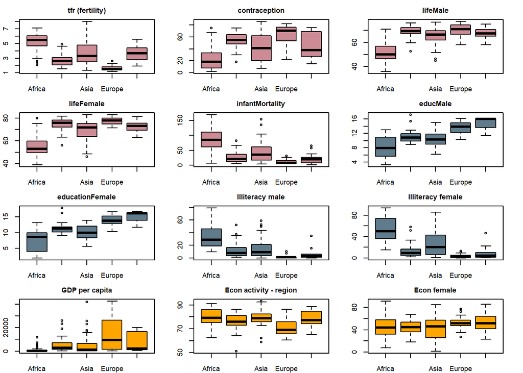

```r
library(graphics)
par(mfrow=c(4,3), mar=c(2,2,2,2))
boxplot(tfr  ~ region, data=data_UN, main = "tfr (fertility)", col = "lightpink3",cex.main=0.85,cex.lab=0.45,cex.axis=0.85)
boxplot(contraception   ~ region, data=data_UN, main = "contraception", col = "lightpink3",cex.main=0.85,cex.lab=0.45,cex.axis=0.85)
boxplot(lifeMale  ~ region, data=data_UN, main = "lifeMale", col = "lightpink3",cex.main=0.85,cex.lab=0.45,cex.axis=0.85)
boxplot(lifeFemale  ~ region, data=data_UN, main = "lifeFemale", col = "lightpink3",cex.main=0.85,cex.lab=0.45,cex.axis=0.85)
boxplot(infantMortality  ~ region, data=data_UN, main = "infantMortality", col = "lightpink3",cex.main=0.85,cex.lab=0.45,cex.axis=0.85)
boxplot(educationMale  ~ region, data=data_UN, main = "educMale", col = "lightskyblue4",cex.main=0.85,cex.lab=0.45,cex.axis=0.85)
boxplot(educationFemale  ~ region, data=data_UN, main = "educationFemale", col = "lightskyblue4",cex.main=0.85,cex.lab=0.45,cex.axis=0.85)
boxplot(illiteracyMale  ~ region, data=data_UN, main = "Illiteracy male", col = "lightskyblue4",cex.main=0.85,cex.lab=0.45,cex.axis=0.85)
boxplot(illiteracyFemale  ~ region, data=data_UN, main = "Illiteracy female", col = "lightskyblue4",cex.main=0.85,cex.lab=0.45,cex.axis=0.85)
boxplot(GDPperCapita  ~ region, data=data_UN, main = "GDP per capita", col = "orange1",cex.main=0.85,cex.lab=0.45,cex.axis=0.85)
boxplot(economicActivityMale  ~ region, data=data_UN, main = "Econ activity - region", col = "orange1",cex.main=0.85,cex.lab=0.45,cex.axis=0.85)
boxplot(economicActivityFemale  ~ region, data=data_UN, main = "Econ female", col = "orange1",cex.main=0.85,cex.lab=0.45,cex.axis=0.85)
```

```r
ok <- complete.cases(data_UN)
sum(!ok)
```

```
## [1] 168
```

```r
table(is.na(data_UN))
```

```
##
## FALSE  TRUE
##  2140   551
```

262 missing values corresponden a “educationMale” y “educationFemale”. Le siguen contraception con 63 missing values.

```r
c5<-apply(is.na(data_UN),2,sum)
as.matrix(c5[c5>0])
```

```
##                        [,1]
## tfr                      10
## contraception            63
## educationMale           131
## educationFemale         131
## lifeMale                 11
## lifeFemale               11
## infantMortality           6
## GDPperCapita             10
## economicActivityMale     42
## economicActivityFemale   42
## illiteracyMale           47
## illiteracyFemale         47
```

En este gráfico se corrobora que el 20.5% delos datos son missing values y que el 63.29% de las variables “educationMale” y “educationFemale” son NA.

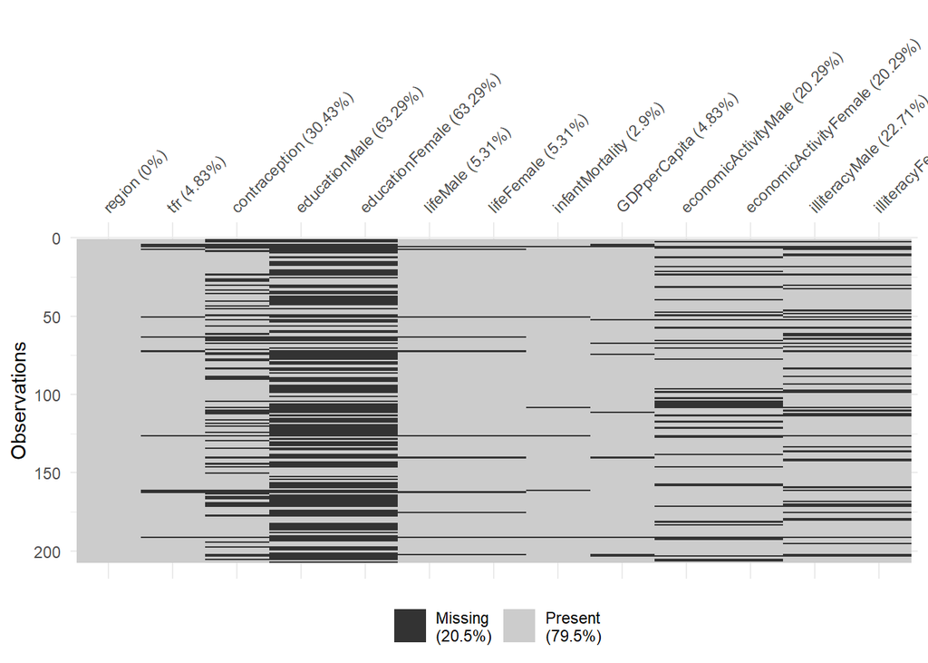

```r
vis_miss(data_UN)
```

Este gráfico siguiente corrobora que las variables con mayor porcentaje de missing “educationMale” y “educationFemale.” La región con mayor porcentaje de missing values en las variables de Educación es Oceanía con el 80%, África con 70%, 60% en América, De realizar una regresión lineal, la region no sería tomada en cuenta para realizar el modelo. De ahí el poder realizar una imputación adecuada.

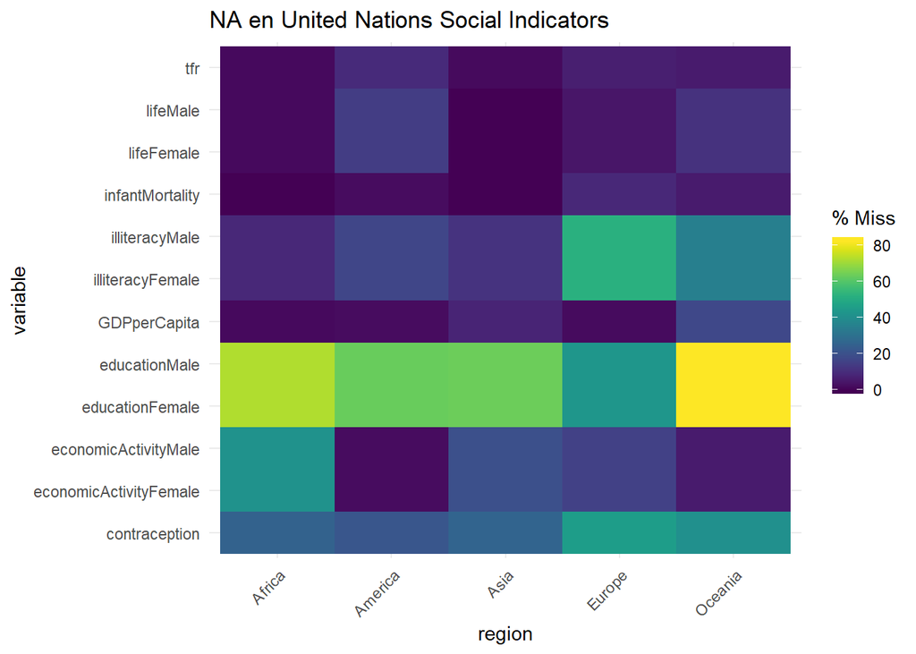

```r
gg_miss_fct(x = data_UN, fct = region)+ labs(title = "NA en United Nations Social Indicators")
```

**Imputación de valores** Se realizan imputaciones por los paquetes: Mice y VIM:

```r
# Imputación mice
init = mice(data_UN , maxit=0,print=F)
pred <- init$pred
imp.mice <- mice(data_UN, pred=pred,m=10, maxit=10,
                 meth=c('norm'),
                 seed=99, diag=FALSE, print=FALSE)
imp.data.mice<-(as.data.frame(mice::complete(imp.mice)))
```

```r
imp.data.irmi <- irmi(data_UN[,1:13],eps=10,maxit=10, robust=TRUE)
imp.data.irmi<-as.data.frame(imp.data.irmi)
```

A continuación, con los resultados de mice podemos visualizar si las gráficas de densidad de los datos originales y los datos ingresados están cerca: azul son los dato originales, rojo las imputaciones. En el caso de la variable “GDPperCápita” las iteraciones no se acercan a la distribución por lo cual más adelante se analizaremos las distribuciones de estas variables por región.

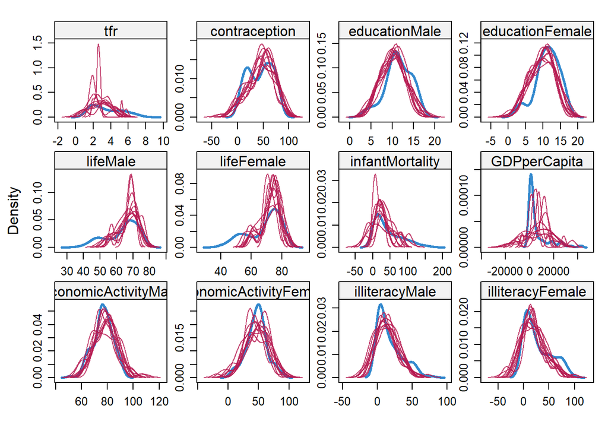

```r
lattice::densityplot(imp.mice,layout = c(4, 3),cex=0.5,cex.axis=0.5,cex.lab=0.5,cex.main=0.5,cex.sub=0.5) # groups = region,
```

```r
mean.data<-round(as.matrix(sapply((na.omit(data_UN[,2:13])),mean)),2)
mean.mice<-round(as.matrix(sapply((imp.data.mice[,2:13]),mean)),2)
mean.irmi<-round(as.matrix(sapply((imp.data.irmi[,2:13]),mean)),2)
mean.data.t<-cbind(mean.data,mean.mice,mean.irmi)

colnames(mean.data.t)<-c("mean.data","mean.mice","mean.irmi")
mean.data.t<-as.data.frame(mean.data.t)
mean.data.t$Dif.mi  <-round(((mean.data.t$mean.data-mean.data.t$mean.mice)/mean.data.t$mean.data),2)
mean.data.t$Dif.ir  <-round(((mean.data.t$mean.data-mean.data.t$mean.irmi)/mean.data.t$mean.data),2)
rownames(mean.data.t)<-c("tfr","contracep","educMale","educFem","lifeMal","lifeFem","InfantMort","GDPperC","economicMal","economicFem","illitMale","illitFem")
mean.data.t
```

```
##             mean.data mean.mice mean.irmi Dif.mi Dif.ir
## tfr              3.10      3.51      3.50  -0.13  -0.13
## contracep       47.85     44.02     45.58   0.08   0.05
## educMale        10.89     10.94     11.13   0.00  -0.02
## educFem         10.75     10.48     10.82   0.03  -0.01
## lifeMal         65.29     63.79     63.94   0.02   0.02
## lifeFem         70.43     68.53     68.73   0.03   0.02
## InfantMort      38.72     43.11     42.91  -0.11  -0.11
## GDPperC       5143.69   6275.88   6365.09  -0.22  -0.24
## economicMal     76.56     76.64     77.73   0.00  -0.02
## economicFem     44.11     47.61     48.08  -0.08  -0.09
## illitMale       15.21     16.24     20.35  -0.07  -0.34
## illitFem        22.57     25.48     25.05  -0.13  -0.11
```

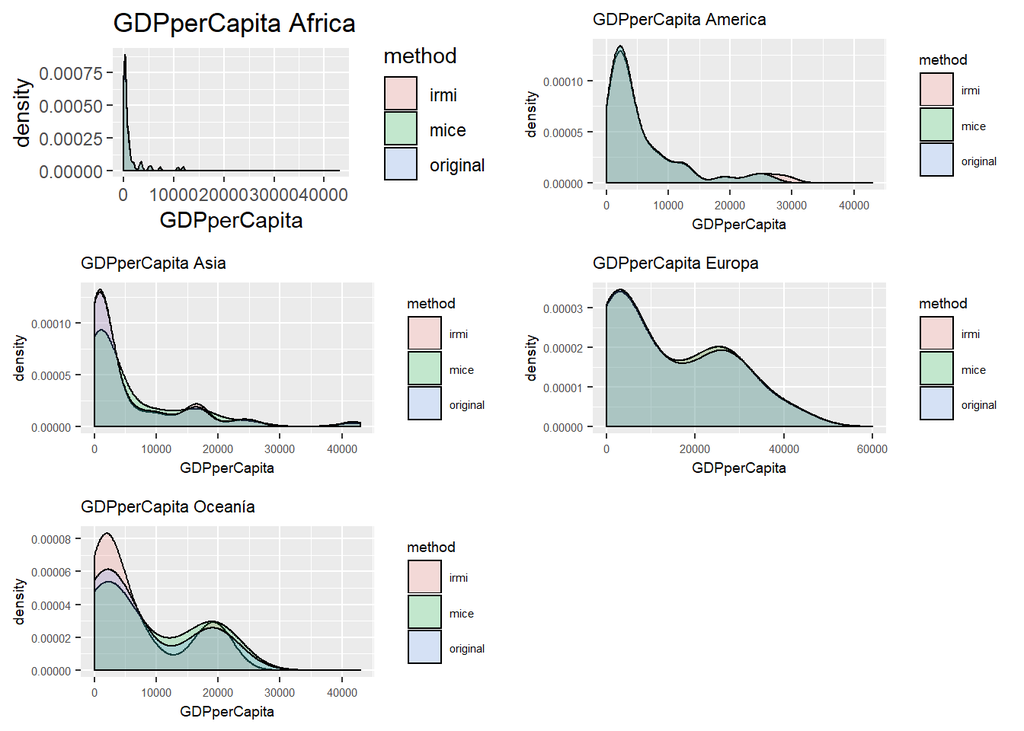

```r
library(ggplot2)
library(ggpubr)
# data5
imp5.1.mice<-imp.data.mice[,1:13]
imp5.3.irmi<-imp.data.irmi[,1:13]

imp5.1.mice$method<-c("mice")
imp5.3.irmi$method<-c("irmi")
data_UN$method<-c("original")
data.imp.t<-rbind(data_UN,imp5.1.mice,imp5.3.irmi)

Africa<-data.imp.t[data.imp.t$region=="Africa",(1:14)]
America<-data.imp.t[data.imp.t$region=="America",(1:14)]
Asia<-data.imp.t[data.imp.t$region=="Asia",(1:14)]
Europa<-data.imp.t[data.imp.t$region=="Europe",(1:14)]
Oceania<-data.imp.t[data.imp.t$region=="Oceania",(1:14)]

p1<-ggplot(Africa, aes(x=GDPperCapita, fill=method)) + geom_density(alpha=0.2) +
  labs(title="GDPperCapita Africa", x="GDPperCapita")+xlim(0,43000)+theme_update(text = element_text(size=7))+ theme(plot.margin = unit(c(0.4,0.4,0.4,0.4), "lines"))

p2<-ggplot(America, aes(x=GDPperCapita, fill=method)) + geom_density(alpha=0.2) +
  labs(title="GDPperCapita America", x="GDPperCapita")+xlim(0,43000)+theme_update(text = element_text(size=7))+ theme(plot.margin = unit(c(0.4,0.4,0.4,0.4), "lines"))

p3<-ggplot(Asia, aes(x=GDPperCapita, fill=method)) + geom_density(alpha=0.2) +
  labs(title="GDPperCapita Asia", x="GDPperCapita")+xlim(0,43000)+theme_update(text = element_text(size=7))+ theme(plot.margin = unit(c(0.4,0.4,0.4,0.4), "lines"))

p4<-ggplot(Europa, aes(x=GDPperCapita, fill=method)) + geom_density(alpha=0.2) +
  labs(title="GDPperCapita Europa", x="GDPperCapita")+xlim(0,60000)+theme_update(text = element_text(size=7))+ theme(plot.margin = unit(c(0.4,0.4,0.4,0.4), "lines"))

p5<-ggplot(Oceania, aes(x=GDPperCapita, fill=method)) + geom_density(alpha=0.2) +
  labs(title="GDPperCapita Oceanía", x="GDPperCapita")+xlim(0,43000)+theme_update(text = element_text(size=7))+ theme(plot.margin = unit(c(0.4,0.4,0.4,0.4), "lines"))

ggarrange(p1, p2, p3, p4, p5, ncol = 2, nrow = 3)
```

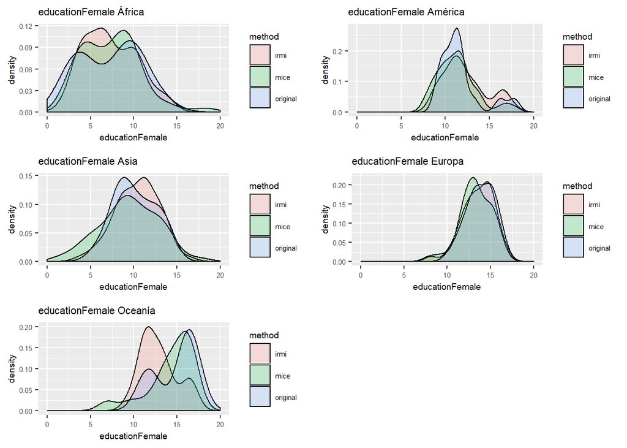

```r
p1<-ggplot(Africa, aes(educationFemale, fill=method)) + geom_density(alpha=0.2) +
  labs(title="educationFemale África", "educationFemale")+xlim(0,20)+theme_update(text = element_text(size=7))+ theme(plot.margin = unit(c(0.4,0.4,0.4,0.4), "lines"))

p2<-ggplot(America, aes(educationFemale, fill=method)) + geom_density(alpha=0.2) +
  labs(title="educationFemale América", "educationFemale")+xlim(0,20)+theme_update(text = element_text(size=7))+ theme(plot.margin = unit(c(0.4,0.4,0.4,0.4), "lines"))

p3<-ggplot(Asia, aes(educationFemale, fill=method)) + geom_density(alpha=0.2) +
  labs(title="educationFemale Asia", "educationFemale")+xlim(0,20)+theme_update(text = element_text(size=7))+ theme(plot.margin = unit(c(0.4,0.4,0.4,0.4), "lines"))

p4<-ggplot(Europa, aes(educationFemale, fill=method)) + geom_density(alpha=0.2) +
  labs(title="educationFemale Europa", "educationFemale")+xlim(0,20)+theme_update(text = element_text(size=7))+ theme(plot.margin = unit(c(0.4,0.4,0.4,0.4), "lines"))

p5<-ggplot(Oceania, aes(educationFemale, fill=method)) + geom_density(alpha=0.2) +
  labs(title="educationFemale Oceanía", "educationFemale")+xlim(0,20)+theme_update(text = element_text(size=7))+ theme(plot.margin = unit(c(0.4,0.4,0.4,0.4), "lines"))

ggarrange(p1, p2, p3, p4, p5, ncol = 2, nrow = 3)
```

**Comparación de modelos realizados con data original e imputada** En la parte inferior se modela la variable “infantMortality”. Se realizan regresiones lineales con la data original y con la data que incorpora las imputaciones con el fin de verificar que las imputaciones no cambien las estimaciones que se obtendrían con la data original.

Antes de evaluar los resultados obtenidos cabe mencionar que la data original únicamente tiene 39 filas completas.

El signo de los coeficientes de regresión se mantiene en las regresiones realizadas con los datos imputados por los distintos métodos, solo cambia para Oceanía.

```r
# lm con data original sin NA
lm.orig<-lm(log(infantMortality)~as.factor(region)+educationFemale+log(GDPperCapita),data=na.omit(data_UN))

# lm con data imputada con mice
lm.mice<-lm(log(infantMortality)~as.factor(region)+educationFemale+log(GDPperCapita),data=imp.data.mice)

# lm con data imputada con irmi
lm.irmi<-lm(log(infantMortality)~as.factor(region)+educationFemale+log(GDPperCapita),data=imp.data.irmi)

# Coeficientes de los modelos
coef_orig=coef(lm.orig)
coef_mice=coef(lm.mice)
coef_irmi=coef(lm.irmi)

list(coef_orig=coef_orig,coef_mice=coef_mice,coef_irmi=coef_irmi)
```

```
## $coef_orig
##              (Intercept) as.factor(region)America    as.factor(region)Asia
##                6.4991453               -0.6610476               -0.5579628
##  as.factor(region)Europe as.factor(region)Oceania          educationFemale
##               -0.9071393                0.2187815               -0.1100236
##        log(GDPperCapita)
##               -0.1955063
##
## $coef_mice
##              (Intercept) as.factor(region)America    as.factor(region)Asia
##                6.6025668               -0.3445335               -0.3582049
##  as.factor(region)Europe as.factor(region)Oceania          educationFemale
##               -0.7191837               -0.1936089               -0.1262843
##        log(GDPperCapita)
##               -0.2164407
##
## $coef_irmi
##              (Intercept) as.factor(region)America    as.factor(region)Asia
##                6.7037656               -0.2823236               -0.2463655
##  as.factor(region)Europe as.factor(region)Oceania          educationFemale
##               -0.6367648               -0.4530625               -0.1051626
##        log(GDPperCapita)
##               -0.2596268
```